# Tugas 1 Praktikum MPDW

David fauzan Akmal

## Library / Packages

*Package* R yang akan digunakan pada perkuliahan Analisis Deret Waktu sesi UTS adalah: `forecast`, `graphics`, `TTR`, `TSA` . Jika *package* tersebut belum ada, silakan install terlebih dahulu. Jika sudah ada, silakan panggil library *package* tersebut.

```r
library(forecast)
```

```r
library(graphics)
library(TTR)
library(TSA)
```

## Impor Data

Baris 1 hingga 100 karena bagian saya adalah data ke-1 hingga ke-100

```r
library(rio)
library(readxl)
data.pm <- read_excel("C://Users/USER/Downloads/Database MPDW.xlsx", sheet=1)
data.pm <-data.pm[1:100,1:2]

data.pm <- data.frame(
  Tanggal = data.pm$Tanggal,
  SS = data.pm$SS
)
```

```r
# Mengecek nilai nol dalam kolom SS
is_zero_ss <- data.pm$SS == 0
print(is_zero_ss)  # Ini akan mengembalikan vektor logika dengan TRUE untuk nilai nol
```

```
##   [1]  TRUE  TRUE FALSE  TRUE FALSE FALSE FALSE FALSE FALSE FALSE FALSE FALSE
##  [13] FALSE FALSE FALSE FALSE FALSE FALSE FALSE  TRUE FALSE FALSE FALSE FALSE
##  [25] FALSE  TRUE  TRUE  TRUE  TRUE  TRUE  TRUE FALSE FALSE FALSE  TRUE  TRUE
##  [37] FALSE FALSE FALSE FALSE  TRUE FALSE  TRUE  TRUE FALSE FALSE FALSE  TRUE
##  [49]  TRUE FALSE FALSE FALSE FALSE  TRUE  TRUE  TRUE  TRUE  TRUE  TRUE  TRUE
##  [61] FALSE  TRUE FALSE  TRUE  TRUE FALSE FALSE FALSE FALSE FALSE FALSE FALSE
##  [73] FALSE FALSE  TRUE FALSE FALSE FALSE FALSE FALSE FALSE FALSE FALSE FALSE
##  [85] FALSE FALSE FALSE FALSE FALSE FALSE FALSE FALSE FALSE FALSE FALSE FALSE
##  [97] FALSE FALSE FALSE FALSE
```

```r
#Berdasarkan sumber yang saya baca, nilai nol akan memengaruhi nilai MAPE dan menyebabkan nilai MAPE menjadi Inf atau NA, maka saya ganti nilai nol dengan nilai lain yang kecil yang aman yaitu 0.001

# Mengganti nilai nol dalam kolom SS dengan 0.001
data.pm$SS[data.pm$SS == 0] <- 0.001

# Menampilkan hasil akhir untuk memverifikasi perubahan
print(data.pm)
```

```
##        Tanggal    SS
## 1   2023-01-01 0.001
## 2   2023-01-02 0.001
## 3   2023-01-03 0.600
## 4   2023-01-04 0.001
## 5   2023-01-05 0.400
## 6   2023-01-06 2.800
## 7   2023-01-07 6.400
## 8   2023-01-08 5.000
## 9   2023-01-09 3.700
## 10  2023-01-10 2.700
## 11  2023-01-11 5.000
## 12  2023-01-12 4.700
## 13  2023-01-13 2.500
## 14  2023-01-14 3.100
```

[output cut: 86 more lines]

## Eksplorasi Data

Melihat data menggunakan fungsi `View()`, struktur data menggunakan fungsi `str()`, dan dimensi data menggunakan fungsi `dim()`.

```r
View(data.pm)
str(data.pm)
```

```
## 'data.frame':    100 obs. of  2 variables:
##  $ Tanggal: POSIXct, format: "2023-01-01" "2023-01-02" ...
##  $ SS     : num  0.001 0.001 0.6 0.001 0.4 2.8 6.4 5 3.7 2.7 ...
```

```r
dim(data.pm)
```

```
## [1] 100   2
```

Mengubah data agar terbaca sebagai data deret waktu dengan fungsi `ts()` .

```r
datapm.ts <- ts(data.pm$SS)
```

Menampilkan ringkasan data

```r
summary(datapm.ts)
```

```
##    Min. 1st Qu.  Median    Mean 3rd Qu.    Max.
##   0.001   0.001   2.350   2.578   4.500   8.200
```

Membuat plot data deret waktu

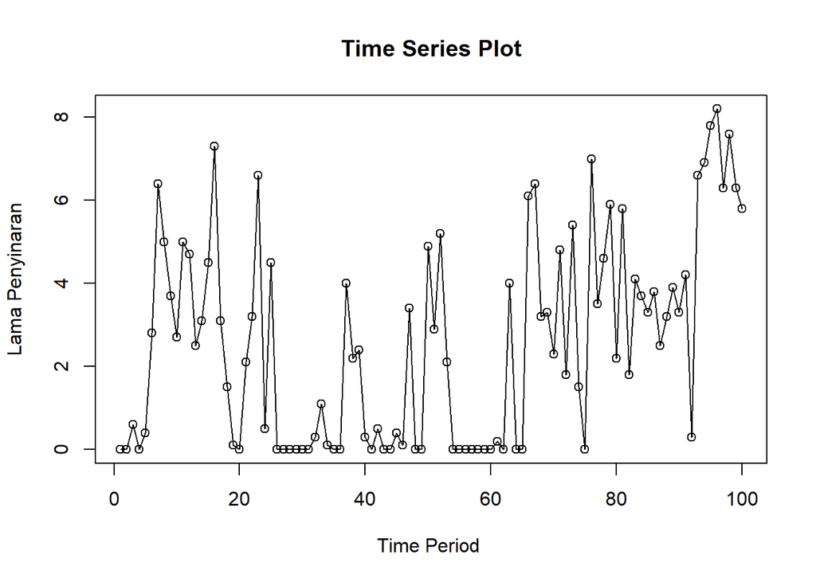

```r
ts.plot(datapm.ts, xlab="Time Period ", ylab="Lama Penyinaran",
        main = "Time Series Plot")
points(datapm.ts)
```

## Single Moving Average & Double Moving Average

### Pembagian Data

Pembagian data latih dan data uji dilakukan dengan perbandingan 80% data latih dan 20% data uji. Saya menggunakan data 1:83 dan 84:100 karena jika dipotong antara 80 81 kurvanya berubah arah, sementara pemotongan di antara 83 dan 84 kurvanya tetap turun ke bawah.

```r
#membagi data latih dan data uji
training_ma <- data.pm[1:83,]
testing_ma <- data.pm[84:100,]
train_ma.ts <- ts(training_ma$SS)
test_ma.ts <- ts(testing_ma$SS)
```

### Eksplorasi Data

Eksplorasi data dilakukan pada keseluruhan data, data latih serta data uji menggunakan plot data deret waktu.

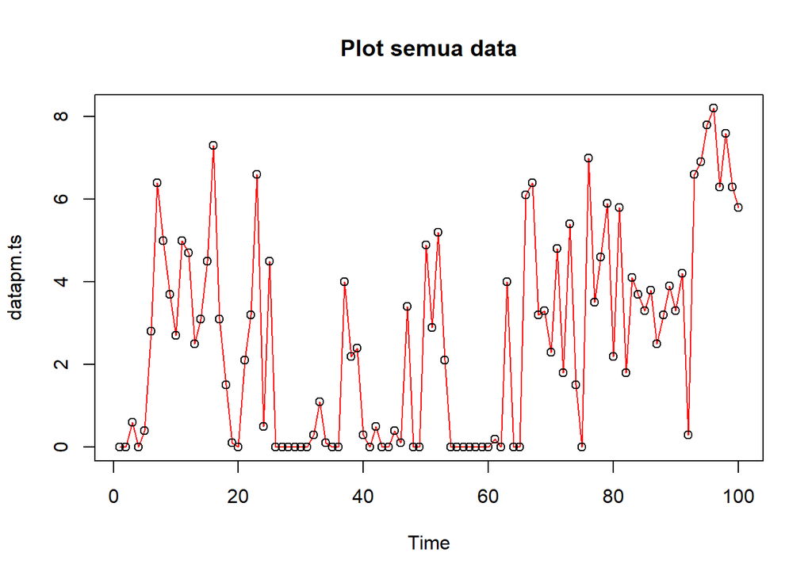

```r
#eksplorasi keseluruhan data
plot(datapm.ts, col="red",main="Plot semua data")
points(datapm.ts)
```

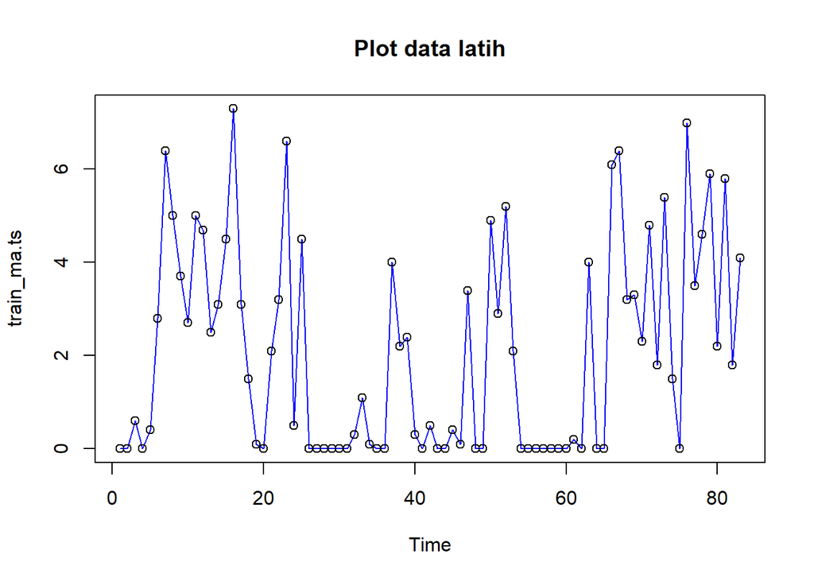

```r
#eksplorasi data latih
plot(train_ma.ts, col="blue",main="Plot data latih")
points(train_ma.ts)
```

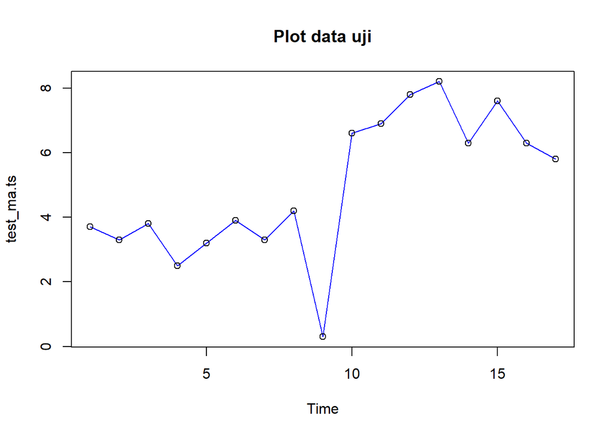

```r
#eksplorasi data uji
plot(test_ma.ts, col="blue",main="Plot data uji")
points(test_ma.ts)
```

Eksplorasi data juga dapat dilakukan menggunakan package `ggplot2` dengan terlebih dahulu memanggil library *package* `ggplot2`.

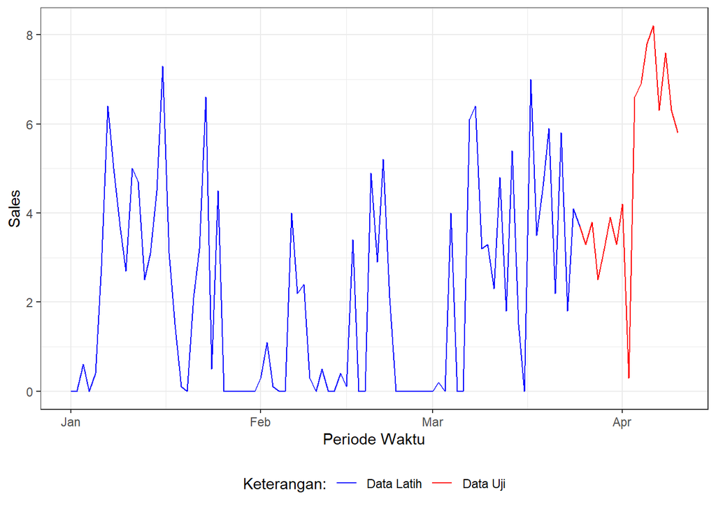

```r
#Eksplorasi dengan GGPLOT
library(ggplot2)
ggplot() +
  geom_line(data = data.pm, aes(x = Tanggal, y = SS, col = "Data Latih")) +
  geom_line(data = testing_ma, aes(x = Tanggal, y = SS, col = "Data Uji")) +
  labs(x = "Periode Waktu", y = "Sales", color = "Legend") +
  scale_colour_manual(name="Keterangan:", breaks = c("Data Latih", "Data Uji"),
                      values = c("blue", "red")) +
  theme_bw() + theme(legend.position = "bottom",
                     plot.caption = element_text(hjust=0.5, size=12))
```

### Single Moving Average (SMA)

Ide dasar dari Single Moving Average (SMA) adalah data suatu periode dipengaruhi oleh data periode sebelumnya. Metode pemulusan ini cocok digunakan untuk pola data stasioner atau konstan. Prinsip dasar metode pemulusan ini adalah data pemulusan pada periode ke-t merupakan rata rata dari m buah data pada periode ke-t hingga periode ke (t-m+1). Data pemulusan pada periode ke-t selanjutnya digunakan sebagai nilai peramalan pada periode ke t+1

Pemulusan menggunakan metode SMA dilakukan dengan fungsi `SMA()`. Dalam hal ini akan dilakukan pemulusan dengan parameter `m=4`.

```r
data.sma<-SMA(train_ma.ts, n=4)
data.sma
```

```
## Time Series:
## Start = 1
## End = 83
## Frequency = 1
##  [1]      NA      NA      NA 0.15075 0.25050 0.95025 2.40025 3.65000 4.47500
## [10] 4.45000 4.10000 4.02500 3.72500 3.82500 3.70000 4.35000 4.50000 4.10000
## [19] 3.00000 1.17525 0.92525 1.35025 2.97525 3.10000 3.70000 2.90025 1.25050
## [28] 1.12575 0.00100 0.00100 0.00100 0.07575 0.35050 0.37525 0.37525 0.30050
## [37] 1.02550 1.55050 2.15025 2.22500 1.22525 0.80025 0.20050 0.12575 0.22550
## [46] 0.12550 0.97525 0.97525 0.87550 2.07550 1.95050 3.25025 3.77500 2.55025
## [55] 1.82550 0.52575 0.00100 0.00100 0.00100 0.00100 0.05075 0.05075 1.05050
## [64] 1.05050 1.00075 2.52550 3.12550 3.92525 4.75000 3.80000 3.40000 3.05000
## [73] 3.57500 3.37500 2.17525 3.47525 3.00025 3.77525 5.25000 4.05000 4.62500
## [82] 3.92500 3.47500
```

Data pemulusan pada periode ke-t selanjutnya digunakan sebagai nilai peramalan pada periode ke t+1 sehingga hasil peramalan 1 periode kedepan adalah sebagai berikut.

```r
data.ramal<-c(NA,data.sma)
data.ramal #forecast 1 periode ke depan
```

```
##  [1]      NA      NA      NA      NA 0.15075 0.25050 0.95025 2.40025 3.65000
## [10] 4.47500 4.45000 4.10000 4.02500 3.72500 3.82500 3.70000 4.35000 4.50000
## [19] 4.10000 3.00000 1.17525 0.92525 1.35025 2.97525 3.10000 3.70000 2.90025
## [28] 1.25050 1.12575 0.00100 0.00100 0.00100 0.07575 0.35050 0.37525 0.37525
## [37] 0.30050 1.02550 1.55050 2.15025 2.22500 1.22525 0.80025 0.20050 0.12575
## [46] 0.22550 0.12550 0.97525 0.97525 0.87550 2.07550 1.95050 3.25025 3.77500
## [55] 2.55025 1.82550 0.52575 0.00100 0.00100 0.00100 0.00100 0.05075 0.05075
## [64] 1.05050 1.05050 1.00075 2.52550 3.12550 3.92525 4.75000 3.80000 3.40000
## [73] 3.05000 3.57500 3.37500 2.17525 3.47525 3.00025 3.77525 5.25000 4.05000
## [82] 4.62500 3.92500 3.47500
```

Selanjutnya akan dilakukan peramalan sejumlah data uji yaitu 17 periode. Pada metode SMA, hasil peramalan 17 periode ke depan akan bernilai sama dengan hasil peramalan 1 periode kedepan. Dalam hal ini akan dilakukan pengguabungan data aktual train, data hasil pemulusan dan data hasil ramalan 17 periode kedepan.

```r
data.gab<-cbind(aktual=c(train_ma.ts,rep(NA,17)),pemulusan=c(data.sma,rep(NA,17)),ramalan=c(data.ramal,rep(data.ramal[length(data.ramal)],16)))
data.gab #forecast 17 periode ke depan
```

```
##        aktual pemulusan ramalan
##   [1,]  0.001        NA      NA
##   [2,]  0.001        NA      NA
##   [3,]  0.600        NA      NA
##   [4,]  0.001   0.15075      NA
##   [5,]  0.400   0.25050 0.15075
##   [6,]  2.800   0.95025 0.25050
##   [7,]  6.400   2.40025 0.95025
##   [8,]  5.000   3.65000 2.40025
##   [9,]  3.700   4.47500 3.65000
##  [10,]  2.700   4.45000 4.47500
##  [11,]  5.000   4.10000 4.45000
##  [12,]  4.700   4.02500 4.10000
##  [13,]  2.500   3.72500 4.02500
##  [14,]  3.100   3.82500 3.72500
```

[output cut: 86 more lines]

Adapun plot data deret waktu dari hasil peramalan yang dilakukan adalah sebagai berikut.

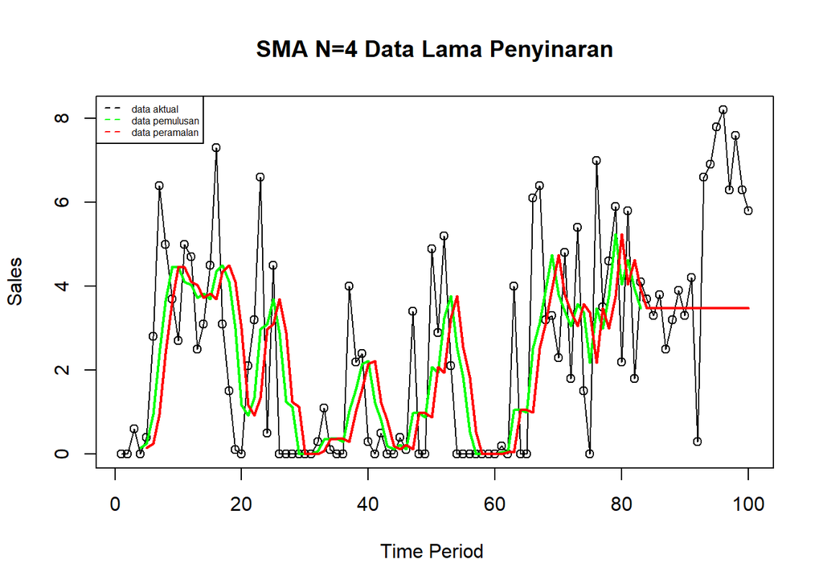

```r
ts.plot(datapm.ts, xlab="Time Period ", ylab="Sales", main= "SMA N=4 Data Lama Penyinaran")
points(datapm.ts)
lines(data.gab[,2],col="green",lwd=2)
lines(data.gab[,3],col="red",lwd=2)
legend("topleft",c("data aktual","data pemulusan","data peramalan"), lty=8, col=c("black","green","red"), cex=0.5)
```

Selanjutnya perhitungan akurasi dilakukan dengan ukuran akurasi *Sum Squares Error* (SSE), *Mean Square Error* (MSE) dan *Mean Absolute Percentage Error* (MAPE). Perhitungan akurasi dilakukan baik pada data latih maupun pada data uji.

```r
#Menghitung nilai keakuratan data latih
error_train.sma = train_ma.ts-data.ramal[1:length(train_ma.ts)]
SSE_train.sma = sum(error_train.sma[5:length(train_ma.ts)]^2)
MSE_train.sma = mean(error_train.sma[5:length(train_ma.ts)]^2)
MAPE_train.sma = mean(abs((error_train.sma[5:length(train_ma.ts)]/train_ma.ts[5:length(train_ma.ts)])*100))

akurasi_train.sma <- matrix(c(SSE_train.sma, MSE_train.sma, MAPE_train.sma))
row.names(akurasi_train.sma)<- c("SSE", "MSE", "MAPE")
colnames(akurasi_train.sma) <- c("Akurasi m = 4")
akurasi_train.sma
```

```
##      Akurasi m = 4
## SSE     398.530219
## MSE       5.044686
## MAPE  40724.996494
```

Dalam hal ini nilai MAPE data latih pada metode pemulusan SMA lebih dari 30%, yang sangat besar, yang menunjukkan bahwa ada masalah dalam perhitungan atau model yang digunakan. Nilai MAPE yang sangat besar biasanya menandakan bahwa ada kesalahan dalam prediksi yang dilakukan oleh model atau data yang digunakan mengandung masalah, pada kasus ini, banyaknya nilai aktual pada data yang sangat kecil. Misalnya, jika nilai aktual mendekati nol, perhitungan MAPE akan menghasilkan nilai yang sangat tinggi karena pembagi dalam perhitungan adalah nilai aktual tersebut.

```r
#Menghitung nilai keakuratan data uji
error_test.sma = test_ma.ts-data.gab[84:100,3]
SSE_test.sma = sum(error_test.sma^2)
MSE_test.sma = mean(error_test.sma^2)
MAPE_test.sma = mean(abs((error_test.sma/test_ma.ts*100)))

akurasi_test.sma <- matrix(c(SSE_test.sma, MSE_test.sma, MAPE_test.sma))
row.names(akurasi_test.sma)<- c("SSE", "MSE", "MAPE")
colnames(akurasi_test.sma) <- c("Akurasi m = 4")
akurasi_test.sma
```

```
##      Akurasi m = 4
## SSE     112.940625
## MSE       6.643566
## MAPE     91.378123
```

Perhitungan akurasi menggunakan data latih menghasilkan nilai MAPE yang lebih dari 30% sehingga nilai akurasi ini menunjukkan predisksi yang sangat buruk dan seringkali menunjukkan bahwa model atau metode yang digunakan mungkin tidak cocok untuk data tersebut.

### Double Moving Average (DMA)

Metode pemulusan Double Moving Average (DMA) pada dasarnya mirip dengan SMA. Namun demikian, metode ini lebih cocok digunakan untuk pola data trend. Proses pemulusan dengan rata rata dalam metode ini dilakukan sebanyak 2 kali.

```r
dma <- SMA(data.sma, n = 4)
At <- 2*data.sma - dma
Bt <- 2/(4-1)*(data.sma - dma)
data.dma<- At+Bt
data.ramal2<- c(NA, data.dma)

t = 1:17
f = c()

for (i in t) {
  f[i] = At[length(At)] + Bt[length(Bt)]*(i)
}

data.gab2 <- cbind(aktual = c(train_ma.ts,rep(NA,17)), pemulusan1 = c(data.sma,rep(NA,17)),pemulusan2 = c(data.dma, rep(NA,17)),At = c(At, rep(NA,17)), Bt = c(Bt,rep(NA,17)),ramalan = c(data.ramal2, f[-1]))
data.gab2
```

```
##        aktual pemulusan1  pemulusan2         At            Bt     ramalan
##   [1,]  0.001         NA          NA         NA            NA          NA
##   [2,]  0.001         NA          NA         NA            NA          NA
##   [3,]  0.600         NA          NA         NA            NA          NA
##   [4,]  0.001    0.15075          NA         NA            NA          NA
##   [5,]  0.400    0.25050          NA         NA            NA          NA
##   [6,]  2.800    0.95025          NA         NA            NA          NA
##   [7,]  6.400    2.40025  4.83743750  3.8625625  9.748750e-01          NA
##   [8,]  5.000    3.65000  6.71208333  5.4872500  1.224833e+00  4.83743750
##   [9,]  3.700    4.47500  7.15187500  6.0811250  1.070750e+00  6.71208333
##  [10,]  2.700    4.45000  5.62697917  5.1561875  4.707917e-01  7.15187500
##  [11,]  5.000    4.10000  3.98541667  4.0312500 -4.583333e-02  5.62697917
##  [12,]  4.700    4.02500  3.62916667  3.7875000 -1.583333e-01  3.98541667
##  [13,]  2.500    3.72500  3.14166667  3.3750000 -2.333333e-01  3.62916667
##  [14,]  3.100    3.82500  3.66875000  3.7312500 -6.250000e-02  3.14166667
```

[output cut: 86 more lines]

Hasil pemulusan menggunakan metode DMA divisualisasikan sebagai berikut

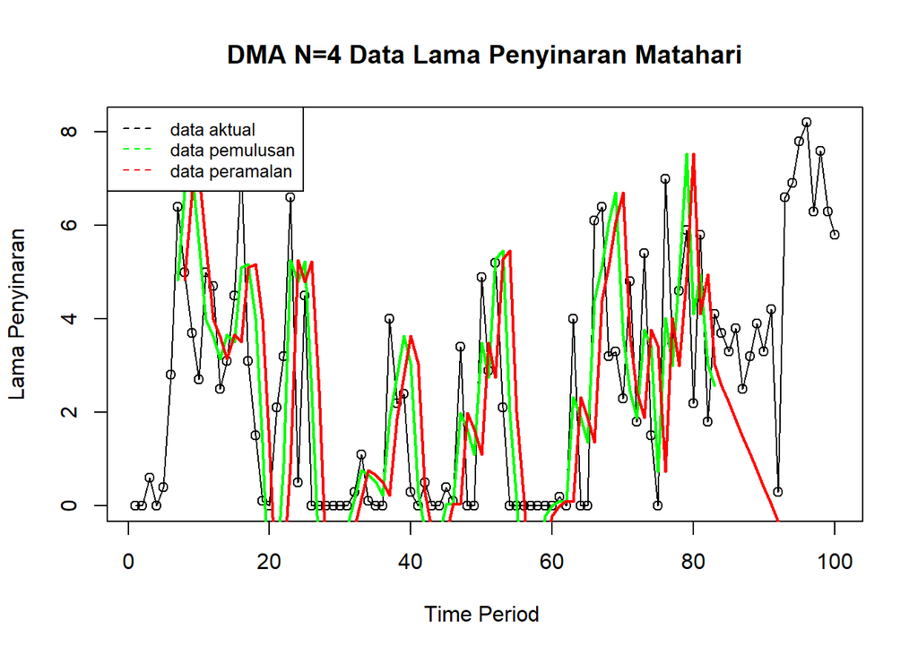

```r
ts.plot(datapm.ts, xlab="Time Period ", ylab="Lama Penyinaran", main= "DMA N=4 Data Lama Penyinaran Matahari")
points(datapm.ts)
lines(data.gab2[,3],col="green",lwd=2)
lines(data.gab2[,6],col="red",lwd=2)
legend("topleft",c("data aktual","data pemulusan","data peramalan"), lty=8, col=c("black","green","red"), cex=0.8)
```

Selanjutnya perhitungan akurasi dilakukan baik pada data latih maupun data uji. Perhitungan akurasi dilakukan dengan ukuran akurasi SSE, MSE dan MAPE.

```r
#Menghitung nilai keakuratan data latih
error_train.dma = train_ma.ts-data.ramal2[1:length(train_ma.ts)]
SSE_train.dma = sum(error_train.dma[8:length(train_ma.ts)]^2)
MSE_train.dma = mean(error_train.dma[8:length(train_ma.ts)]^2)
MAPE_train.dma = mean(abs((error_train.dma[8:length(train_ma.ts)]/train_ma.ts[8:length(train_ma.ts)])*100))

akurasi_train.dma <- matrix(c(SSE_train.dma, MSE_train.dma, MAPE_train.dma))
row.names(akurasi_train.dma)<- c("SSE", "MSE", "MAPE")
colnames(akurasi_train.dma) <- c("Akurasi m = 4")
akurasi_train.dma
```

```
##      Akurasi m = 4
## SSE     547.740061
## MSE       7.207106
## MAPE  58886.228071
```

Perhitungan akurasi menggunakan data latih menghasilkan nilai mape jauh lebih dari 30%, yang sangat besar, yang menunjukkan bahwa ada masalah dalam perhitungan atau model yang digunakan. Nilai MAPE yang sangat besar biasanya menandakan bahwa ada kesalahan dalam prediksi yang dilakukan oleh model atau data yang digunakan mengandung masalah, pada kasus ini, banyaknya nilai aktual pada data yang sangat kecil. Misalnya, jika nilai aktual mendekati nol, perhitungan MAPE akan menghasilkan nilai yang sangat tinggi karena pembagi dalam perhitungan adalah nilai aktual tersebut.

```r
#Menghitung nilai keakuratan data uji
error_test.dma = test_ma.ts-data.gab2[84:100,6]
SSE_test.dma = sum(error_test.dma^2)
MSE_test.dma = mean(error_test.dma^2)
MAPE_test.dma = mean(abs((error_test.dma/test_ma.ts*100)))

akurasi_test.dma <- matrix(c(SSE_test.dma, MSE_test.dma, MAPE_test.dma))
row.names(akurasi_test.dma)<- c("SSE", "MSE", "MAPE")
colnames(akurasi_test.dma) <- c("Akurasi m = 4")
akurasi_test.dma
```

```
##      Akurasi m = 4
## SSE      687.95285
## MSE       40.46781
## MAPE     101.96000
```

Perhitungan akurasi menggunakan data latih menghasilkan nilai MAPE yang lebih dari 30% sehingga nilai akurasi ini menunjukkan predisksi yang sangat buruk dan seringkali menunjukkan bahwa model atau metode yang digunakan mungkin tidak cocok untuk data tersebut.

Pada data uji dan data latih, metode SMA lebih baik dibandingkan dengan metode DMA.

## Single Exponential Smoothing & Double Exponential Smoothing

Metode *Exponential Smoothing* adalah metode pemulusan dengan melakukan pembobotan menurun secara eksponensial. Nilai yang lebih baru diberi bobot yang lebih besar dari nilai terdahulu. Terdapat satu atau lebih parameter pemulusan yang ditentukan secara eksplisit, dan hasil pemilihan parameter tersebut akan menentukan bobot yang akan diberikan pada nilai pengamatan. Ada dua macam model, yaitu model tunggal dan ganda.

### Pembagian Data

```r
#membagi training dan testing
training<-data.pm[1:83,]
testing<-data.pm[84:100,]
train.ts <- ts(training$SS)
test.ts <- ts(testing$SS)
```

### Eksplorasi

Eksplorasi dilakukan dengan membuat plot data deret waktu untuk keseluruhan data, data latih, dan data uji.

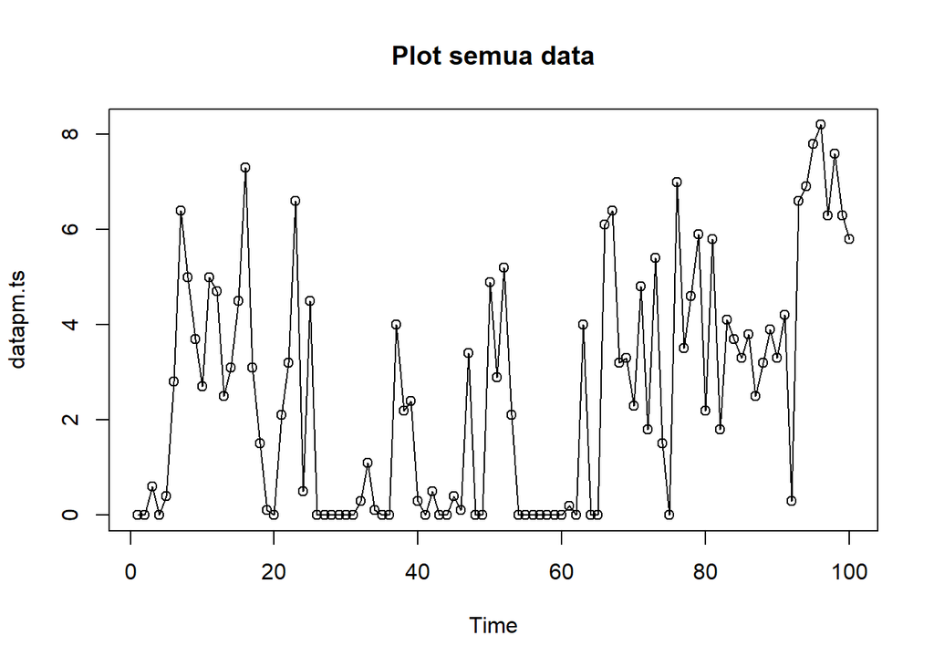

```r
#eksplorasi data
plot(datapm.ts, col="black",main="Plot semua data")
points(datapm.ts)
```

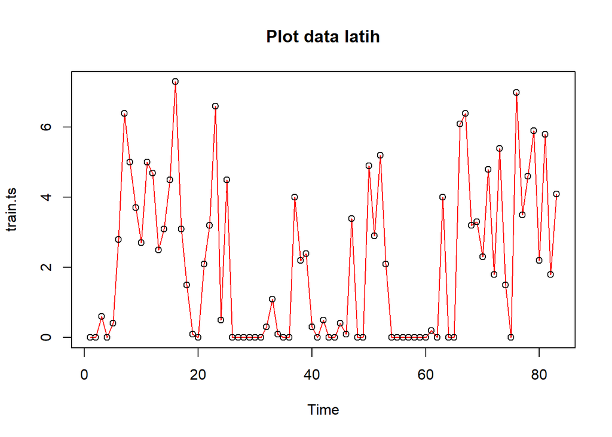

```r
plot(train.ts, col="red",main="Plot data latih")
points(train.ts)
```

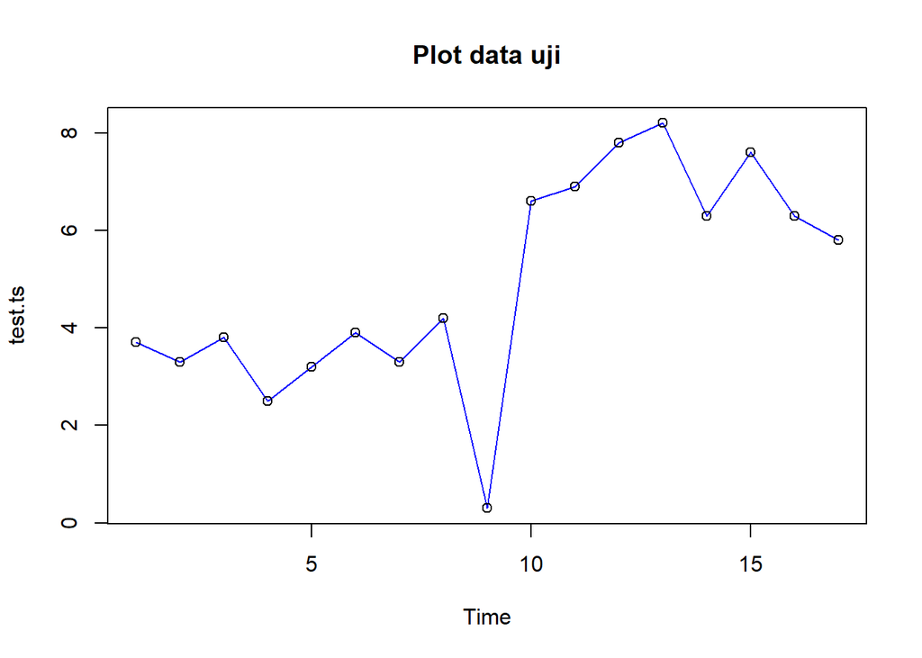

```r
plot(test.ts, col="blue",main="Plot data uji")
points(test.ts)
```

Eksplorasi data juga dapat dilakukan menggunakan package `ggplot2` .

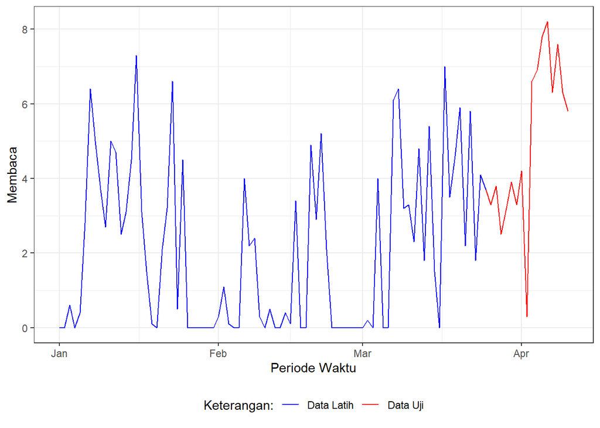

```r
#Eksplorasi dengan GGPLOT
library(ggplot2)
ggplot() +
  geom_line(data = data.pm, aes(x = Tanggal, y = SS, col = "Data Latih")) +
  geom_line(data = testing, aes(x = Tanggal, y = SS, col = "Data Uji")) +
  labs(x = "Periode Waktu", y = "Membaca", color = "Legend") +
  scale_colour_manual(name="Keterangan:", breaks = c("Data Latih", "Data Uji"),
                      values = c("blue", "red")) +
  theme_bw() + theme(legend.position = "bottom",
                     plot.caption = element_text(hjust=0.5, size=12))
```

### SES

Single Exponential Smoothing merupakan metode pemulusan yang tepat digunakan untuk data dengan pola stasioner atau konstan.

Nilai pemulusan pada periode ke-t didapat dari persamaan:

$$\tilde{y}_T=\lambda y_t+(1-\lambda)\tilde{y}_{T-1}$$

Nilai parameter $\lambda$ adalah nilai antara 0 dan 1.

Nilai pemulusan periode ke-t bertindak sebagai nilai ramalan pada periode ke-$(T+\tau)$.

$$\tilde{y}_{T+\tau}(T)=\tilde{y}_T$$

Pemulusan dengan metode SES dapat dilakukan dengan dua fungsi dari *packages* berbeda, yaitu (1) fungsi `ses()` dari *packages* `forecast` dan (2) fungsi `HoltWinters` dari *packages* `stats` .

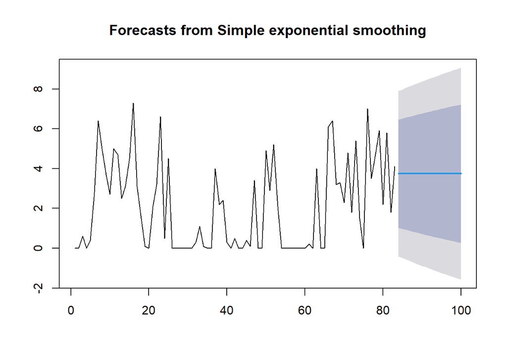

```r
#Cara 1 (fungsi ses)
ses.1 <- ses(train.ts, h = 17, alpha = 0.2)
plot(ses.1)
```

```r
ses.1
```

```
##     Point Forecast     Lo 80    Hi 80      Lo 95    Hi 95
##  84       3.743572 1.0271341 6.460010 -0.4108613 7.898005
##  85       3.743572 0.9733380 6.513806 -0.4931353 7.980279
##  86       3.743572 0.9205669 6.566577 -0.5738417 8.060986
##  87       3.743572 0.8687644 6.618380 -0.6530669 8.140211
##  88       3.743572 0.8178788 6.669265 -0.7308896 8.218034
##  89       3.743572 0.7678634 6.719281 -0.8073816 8.294526
##  90       3.743572 0.7186748 6.768469 -0.8826091 8.369753
##  91       3.743572 0.6702733 6.816871 -0.9566327 8.443777
##  92       3.743572 0.6226225 6.864522 -1.0295084 8.516653
##  93       3.743572 0.5756883 6.911456 -1.1012881 8.588432
##  94       3.743572 0.5294393 6.957705 -1.1720197 8.659164
##  95       3.743572 0.4838465 7.003298 -1.2417479 8.728892
##  96       3.743572 0.4388827 7.048261 -1.3105142 8.797658
##  97       3.743572 0.3945224 7.092622 -1.3783573 8.865501
##  98       3.743572 0.3507421 7.136402 -1.4453135 8.932458
##  99       3.743572 0.3075196 7.179624 -1.5114166 8.998561
## 100       3.743572 0.2648341 7.222310 -1.5766985 9.063843
```

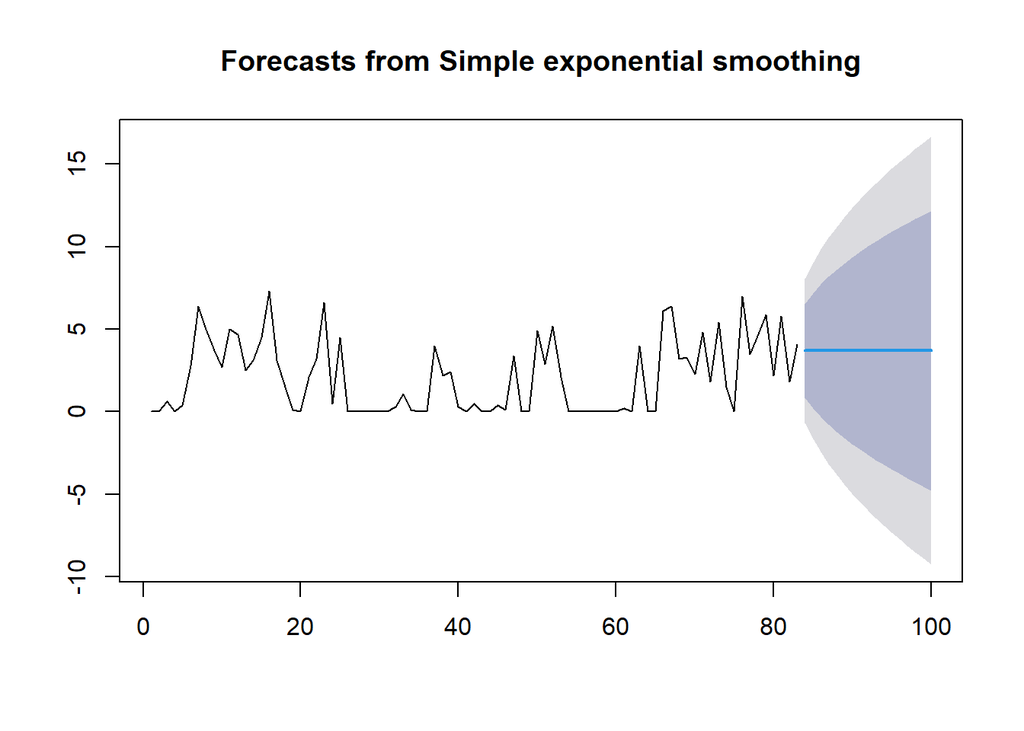

```r
ses.2<- ses(train.ts, h = 17, alpha = 0.7)
plot(ses.2)
```

```r
ses.2
```

```
##     Point Forecast      Lo 80     Hi 80      Lo 95     Hi 95
##  84       3.699163  0.8492768  6.549049 -0.6593618  8.057687
##  85       3.699163  0.2204336  7.177892 -1.6210944  9.019420
##  86       3.699163 -0.3109823  7.709308 -2.4338249  9.832150
##  87       3.699163 -0.7797847  8.178110 -3.1507962 10.549122
##  88       3.699163 -1.2039665  8.602292 -3.7995264 11.197852
##  89       3.699163 -1.5942655  8.992591 -4.3964372 11.794763
##  90       3.699163 -1.9576994  9.356025 -4.9522614 12.350587
##  91       3.699163 -2.2991534  9.697479 -5.4744701 12.872796
##  92       3.699163 -2.6221902 10.020516 -5.9685123 13.366838
##  93       3.699163 -2.9295030 10.327829 -6.4385067 13.836832
##  94       3.699163 -3.2231863 10.621512 -6.8876565 14.285982
##  95       3.699163 -3.5049071 10.903233 -7.3185114 14.716837
##  96       3.699163 -3.7760181 11.174344 -7.7331399 15.131465
##  97       3.699163 -4.0376348 11.435960 -8.1332480 15.531574
##  98       3.699163 -4.2906897 11.689015 -8.5202621 15.918588
##  99       3.699163 -4.5359723 11.934298 -8.8953895 16.293715
## 100       3.699163 -4.7741575 12.172483 -9.2596623 16.657988
```

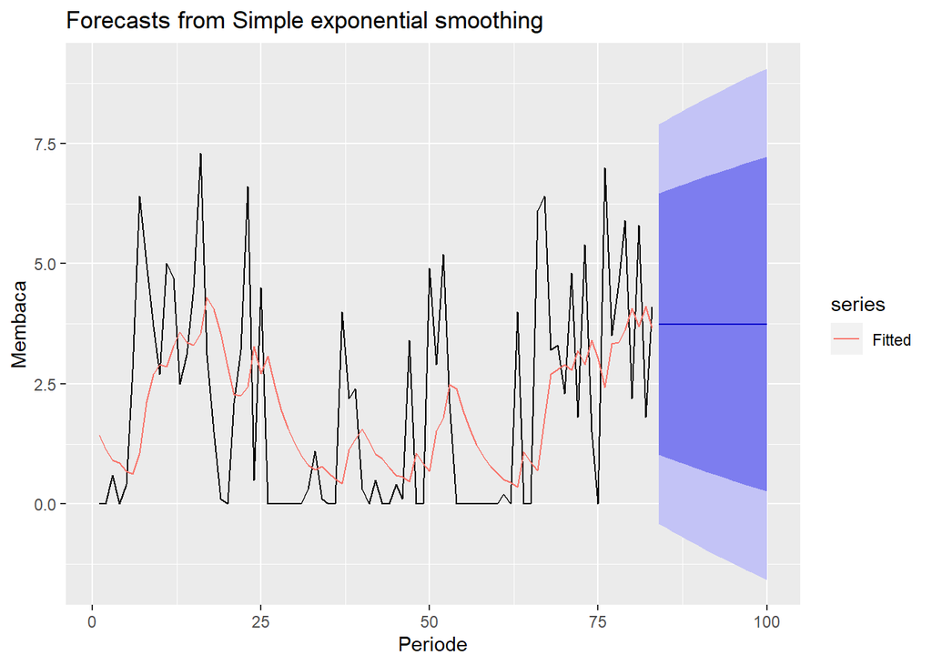

```r
autoplot(ses.1) +
  autolayer(fitted(ses.1), series="Fitted") +
  ylab("Membaca") + xlab("Periode")
```

Pada fungsi `ses()` , terdapat beberapa argumen yang umum digunakan, yaitu nilia `y` , `gamma` , `beta` , `alpha` , dan `h` .

Nilai `y` adalah nilai data deret waktu, `gamma` adalah parameter pemulusan untuk komponen musiman, `beta` adalah parameter pemulusan untuk tren, dan `alpha` adalah parameter pemulusan untuk stasioner, serta `h` adalah banyaknya periode yang akan diramalkan.

Kasus di atas merupakan contoh inisialisasi nilai parameter $\lambda$ dengan nilai `alpha` 0,2 dan 0,7 dan banyak periode data yang akan diramalkan adalah sebanyak 17 periode. Selanjutnya akan digunakan fungsi `HoltWinters()` dengan nilai inisialisasi parameter dan panjang periode peramalan yang sama dengan fungsi `ses()` .

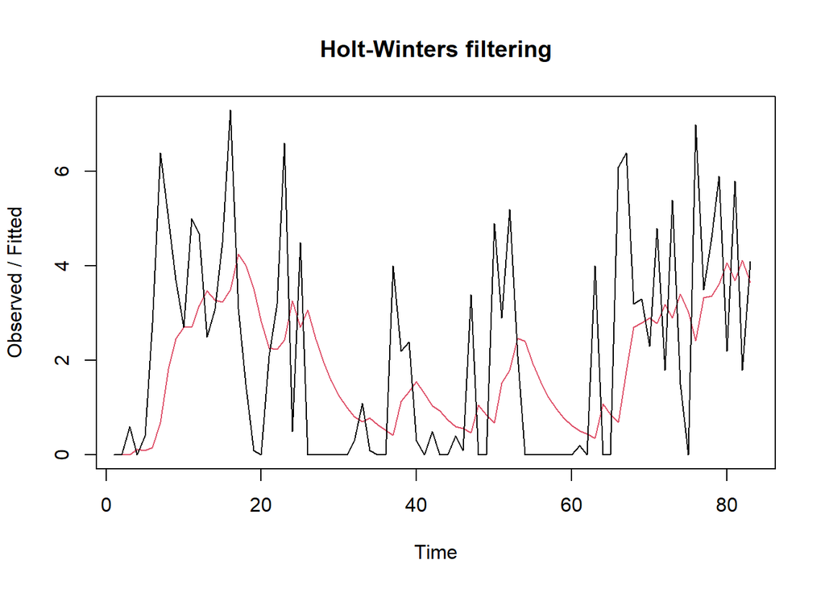

```r
#Cara 2 (fungsi Holtwinter)
ses1<- HoltWinters(train.ts, gamma = FALSE, beta = FALSE, alpha = 0.2)
plot(ses1)
```

```r
#ramalan
ramalan1<- forecast(ses1, h=17)
ramalan1
```

```
##     Point Forecast     Lo 80    Hi 80      Lo 95    Hi 95
##  84       3.743572 1.0217988 6.465345 -0.4190209 7.906165
##  85       3.743572 0.9678971 6.519247 -0.5014565 7.988601
##  86       3.743572 0.9150223 6.572122 -0.5823214 8.069465
##  87       3.743572 0.8631180 6.624026 -0.6617022 8.148846
##  88       3.743572 0.8121326 6.675011 -0.7396777 8.226822
##  89       3.743572 0.7620189 6.725125 -0.8163200 8.303464
##  90       3.743572 0.7127337 6.774410 -0.8916953 8.378839
##  91       3.743572 0.6642372 6.822907 -0.9658642 8.453008
##  92       3.743572 0.6164927 6.870651 -1.0388831 8.526027
##  93       3.743572 0.5694663 6.917678 -1.1108038 8.597948
##  94       3.743572 0.5231265 6.964018 -1.1816743 8.668818
##  95       3.743572 0.4774442 7.009700 -1.2515395 8.738684
##  96       3.743572 0.4323920 7.054752 -1.3204408 8.807585
##  97       3.743572 0.3879447 7.099199 -1.3884172 8.875561
##  98       3.743572 0.3440784 7.143066 -1.4555048 8.942649
##  99       3.743572 0.3007710 7.186373 -1.5217378 9.008882
## 100       3.743572 0.2580016 7.229142 -1.5871479 9.074292
```

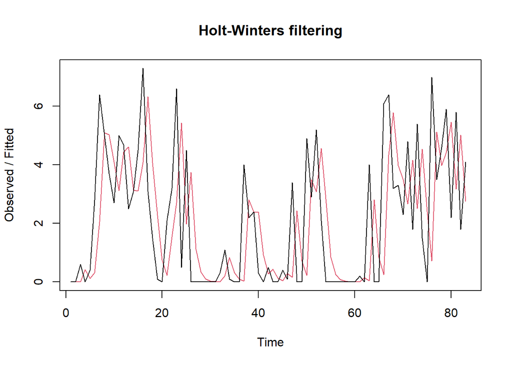

```r
ses2<- HoltWinters(train.ts, gamma = FALSE, beta = FALSE, alpha = 0.7)
plot(ses2)
```

```r
#ramalan
ramalan2<- forecast(ses2, h=17)
ramalan2
```

```
##     Point Forecast      Lo 80     Hi 80      Lo 95     Hi 95
##  84       3.699163  0.8504785  6.547847 -0.6575239  8.055849
##  85       3.699163  0.2219004  7.176425 -1.6188510  9.017177
##  86       3.699163 -0.3092913  7.707617 -2.4312388  9.829564
##  87       3.699163 -0.7778960  8.176222 -3.1479078 10.546233
##  88       3.699163 -1.2018990  8.600225 -3.7963644 11.194690
##  89       3.699163 -1.5920335  8.990359 -4.3930236 11.791349
##  90       3.699163 -1.9553141  9.353640 -4.9486133 12.346939
##  91       3.699163 -2.2966241  9.694950 -5.4706019 12.868927
##  92       3.699163 -2.6195247 10.017850 -5.9644357 13.362761
##  93       3.699163 -2.9267079 10.325033 -6.4342319 13.832557
##  94       3.699163 -3.2202673 10.618593 -6.8831924 14.281518
##  95       3.699163 -3.5018694 10.900195 -7.3138655 14.712191
##  96       3.699163 -3.7728661 11.171192 -7.7283192 15.126645
##  97       3.699163 -4.0343724 11.432698 -8.1282586 15.526584
##  98       3.699163 -4.2873206 11.685646 -8.5151096 15.913435
##  99       3.699163 -4.5324998 11.930825 -8.8900787 16.288404
## 100       3.699163 -4.7705845 12.168910 -9.2541979 16.652523
```

Fungsi `HoltWinters` memiliki argumen yang sama dengan fungsi `ses()` . Argumen-argumen kedua fungsi dapat dilihat lebih lanjut dengan `?ses()` atau `?HoltWinters` .

Nilai parameter $\alpha$ dari kedua fungsi dapat dioptimalkan menyesuaikan dari *error*-nya paling minimumnya. Caranya adalah dengan membuat parameter $\alpha =$ `NULL` .

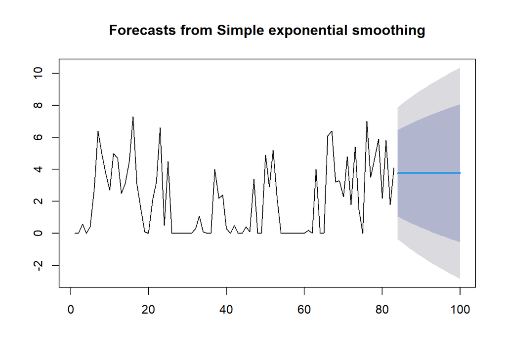

```r
#SES
ses.opt <- ses(train.ts, h = 17, alpha = NULL)
plot(ses.opt)
```

```r
ses.opt
```

```
##     Point Forecast       Lo 80    Hi 80      Lo 95     Hi 95
##  84       3.760656  1.06284662 6.458465 -0.3652873  7.886599
##  85       3.760656  0.93483397 6.586478 -0.5610658  8.082377
##  86       3.760656  0.81237432 6.708937 -0.7483516  8.269663
##  87       3.760656  0.69480220 6.826509 -0.9281627  8.449474
##  88       3.760656  0.58157528 6.939736 -1.1013283  8.622640
##  89       3.760656  0.47224470 7.049067 -1.2685350  8.789847
##  90       3.760656  0.36643391 7.154878 -1.4303586  8.951670
##  91       3.760656  0.26382340 7.257488 -1.5872879  9.108599
##  92       3.760656  0.16413922 7.357172 -1.7397417  9.261053
##  93       3.760656  0.06714444 7.454167 -1.8880824  9.409394
##  94       3.760656 -0.02736753 7.548679 -2.0326260  9.553938
##  95       3.760656 -0.11957814 7.640890 -2.1736499  9.694962
##  96       3.760656 -0.20964772 7.730959 -2.3113995  9.832711
##  97       3.760656 -0.29771884 7.819030 -2.4460926  9.967404
##  98       3.760656 -0.38391889 7.905231 -2.5779242 10.099236
##  99       3.760656 -0.46836229 7.989674 -2.7070692 10.228381
## 100       3.760656 -0.55115224 8.072464 -2.8336856 10.354997
```

```r
#Lamda Optimum Holt Winter
sesopt<- HoltWinters(train.ts, gamma = FALSE, beta = FALSE,alpha = NULL)
sesopt
```

```
## Holt-Winters exponential smoothing without trend and without seasonal component.
##
## Call:
## HoltWinters(x = train.ts, alpha = NULL, beta = FALSE, gamma = FALSE)
##
## Smoothing parameters:
##  alpha: 0.3305491
##  beta : FALSE
##  gamma: FALSE
##
## Coefficients:
##      [,1]
## a 3.75318
```

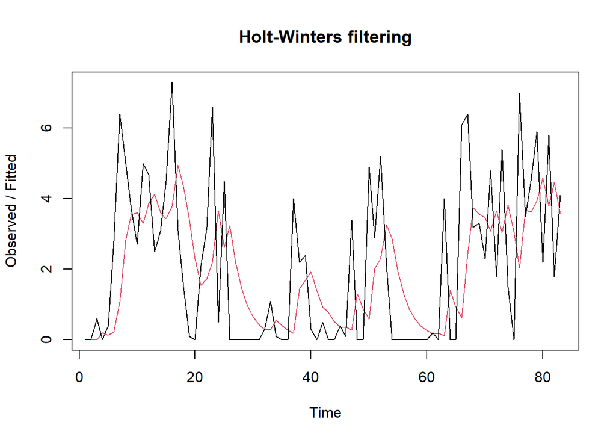

```r
plot(sesopt)
```

```r
#ramalan
ramalanopt<- forecast(sesopt, h=17)
ramalanopt
```

```
##     Point Forecast       Lo 80    Hi 80      Lo 95     Hi 95
##  84        3.75318  1.05769588 6.448664 -0.3692072  7.875567
##  85        3.75318  0.91425462 6.592105 -0.5885817  8.094941
##  86        3.75318  0.77772036 6.728639 -0.7973928  8.303753
##  87        3.75318  0.64718213 6.859178 -0.9970338  8.503394
##  88        3.75318  0.52191315 6.984447 -1.1886161  8.694976
##  89        3.75318  0.40132258 7.105037 -1.3730435  8.879403
##  90        3.75318  0.28492239 7.221437 -1.5510622  9.057422
##  91        3.75318  0.17230391 7.334056 -1.7232973  9.229657
##  92        3.75318  0.06312088 7.443239 -1.8902784  9.396638
##  93        3.75318 -0.04292313 7.549283 -2.0524587  9.558818
##  94        3.75318 -0.14608425 7.652444 -2.2102300  9.716590
##  95        3.75318 -0.24658554 7.752945 -2.3639335  9.870293
##  96        3.75318 -0.34462272 7.850983 -2.5138684 10.020228
##  97        3.75318 -0.44036859 7.946728 -2.6602991 10.166659
##  98        3.75318 -0.53397669 8.040336 -2.8034603 10.309820
##  99        3.75318 -0.62558412 8.131944 -2.9435618 10.449922
## 100        3.75318 -0.71531392 8.221674 -3.0807917 10.587151
```

Setelah dilakukan peramalan, akan dilakukan perhitungan keakuratan hasil peramalan. Perhitungan akurasi ini dilakukan baik pada data latih dan data uji.

#### Akurasi Data Latih

Perhitungan akurasi data dapat dilakukan dengan cara langsung maupun manual. Secara langsung, nilai akurasi dapat diambil dari objek yang tersimpan pada hasil SES, yaitu *sum of squared errors* (SSE). Nilai akurasi lain dapat dihitung pula dari nilai SSE tersebut.

```r
#Keakuratan Metode
#Pada data training
SSE1<-ses1$SSE
MSE1<-ses1$SSE/length(train.ts)
RMSE1<-sqrt(MSE1)

akurasi1 <- matrix(c(SSE1,MSE1,RMSE1))
row.names(akurasi1)<- c("SSE", "MSE", "RMSE")
colnames(akurasi1) <- c("Akurasi lamda=0.2")
akurasi1
```

```
##      Akurasi lamda=0.2
## SSE         369.626776
## MSE           4.453335
## RMSE          2.110293
```

```r
SSE2<-ses2$SSE
MSE2<-ses2$SSE/length(train.ts)
RMSE2<-sqrt(MSE2)

akurasi2 <- matrix(c(SSE2,MSE2,RMSE2))
row.names(akurasi2)<- c("SSE", "MSE", "RMSE")
colnames(akurasi2) <- c("Akurasi lamda=0.7")
akurasi2
```

```
##      Akurasi lamda=0.7
## SSE         400.562867
## MSE           4.826059
## RMSE          2.196829
```

```r
#Cara Manual
fitted1<-ramalan1$fitted
sisaan1<-ramalan1$residuals
head(sisaan1)
```

```
## Time Series:
## Start = 1
## End = 6
## Frequency = 1
## [1]        NA  0.000000  0.599000 -0.119800  0.303160  2.642528
```

```r
resid1<-training$SS-ramalan1$fitted
head(resid1)
```

```
## Time Series:
## Start = 1
## End = 6
## Frequency = 1
## [1]        NA  0.000000  0.599000 -0.119800  0.303160  2.642528
```

```r
#Cara Manual
SSE.1=sum(sisaan1[2:length(train.ts)]^2)
SSE.1
```

```
## [1] 369.6268
```

```r
MSE.1 = SSE.1/length(train.ts)
MSE.1
```

```
## [1] 4.453335
```

```r
MAPE.1 = sum(abs(sisaan1[2:length(train.ts)]/train.ts[2:length(train.ts)])*
               100)/length(train.ts)
MAPE.1
```

```
## [1] 42527.17
```

```r
akurasi.1 <- matrix(c(SSE.1,MSE.1,MAPE.1))
row.names(akurasi.1)<- c("SSE", "MSE", "MAPE")
colnames(akurasi.1) <- c("Akurasi lamda=0.2")
akurasi.1
```

```
##      Akurasi lamda=0.2
## SSE         369.626776
## MSE           4.453335
## MAPE      42527.174218
```

```r
fitted2<-ramalan2$fitted
sisaan2<-ramalan2$residuals
head(sisaan2)
```

```
## Time Series:
## Start = 1
## End = 6
## Frequency = 1
## [1]        NA  0.000000  0.599000 -0.419300  0.273210  2.481963
```

```r
resid2<-training$SS-ramalan2$fitted
head(resid2)
```

```
## Time Series:
## Start = 1
## End = 6
## Frequency = 1
## [1]        NA  0.000000  0.599000 -0.419300  0.273210  2.481963
```

```r
SSE.2=sum(sisaan2[2:length(train.ts)]^2)
SSE.2
```

```
## [1] 400.5629
```

```r
MSE.2 = SSE.2/length(train.ts)
MSE.2
```

```
## [1] 4.826059
```

```r
MAPE.2 = sum(abs(sisaan2[2:length(train.ts)]/train.ts[2:length(train.ts)])*
               100)/length(train.ts)
MAPE.2
```

```
## [1] 26398.58
```

```r
akurasi.2 <- matrix(c(SSE.2,MSE.2,MAPE.2))
row.names(akurasi.2)<- c("SSE", "MSE", "MAPE")
colnames(akurasi.2) <- c("Akurasi lamda=0.7")
akurasi.2
```

```
##      Akurasi lamda=0.7
## SSE         400.562867
## MSE           4.826059
## MAPE      26398.584955
```

#### Akurasi Data Uji

Akurasi data uji dapat dihitung dengan cara yang hampir sama dengan perhitungan akurasi data latih.

```r
selisih1<-ramalan1$mean-testing$SS
SSEtesting1<-sum(selisih1^2)
MSEtesting1<-SSEtesting1/length(testing)

selisih2<-ramalan2$mean-testing$SS
SSEtesting2<-sum(selisih2^2)
MSEtesting2<-SSEtesting2/length(testing)

selisihopt<-ramalanopt$mean-testing$SS
SSEtestingopt<-sum(selisihopt^2)
MSEtestingopt<-SSEtestingopt/length(testing)

akurasitesting1 <- matrix(c(SSEtesting1,SSEtesting2,SSEtestingopt))
row.names(akurasitesting1)<- c("SSE1", "SSE2", "SSEopt")
akurasitesting1
```

```
##            [,1]
## SSE1   100.9397
## SSE2   102.7548
## SSEopt 100.5558
```

```r
akurasitesting2 <- matrix(c(MSEtesting1,MSEtesting2,MSEtestingopt))
row.names(akurasitesting2)<- c("MSE1", "MSE2", "MSEopt")
akurasitesting2
```

```
##            [,1]
## MSE1   50.46984
## MSE2   51.37742
## MSEopt 50.27790
```

Selain dengan cara di atas, perhitungan nilai akurasi dapat menggunakan fungsi `accuracy()` dari *package* `forecast` . Penggunaannya yaitu dengan menuliskan `accuracy(hasil ramalan, kondisi aktual)` . Contohnya adalah sebagai berikut.

```r
#cara lain
accuracy(ramalanopt,testing$SS)
```

```
##                     ME     RMSE      MAE          MPE        MAPE      MASE
## Training set 0.1384312 2.095012 1.609052 -37560.25092 37602.16460 0.9234675
## Test set     1.1703495 2.432087 1.902006    -51.18426    95.56595 1.0915997
##                   ACF1
## Training set 0.0568436
## Test set            NA
```

### DES

Metode pemulusan *Double Exponential Smoothing* (DES) digunakan untuk data yang memiliki pola tren. Metode DES adalah metode semacam SES, hanya saja dilakukan dua kali, yaitu pertama untuk tahapan ‘level’ dan kedua untuk tahapan ‘tren’. Pemulusan menggunakan metode ini akan menghasilkan peramalan tidak konstan untuk periode berikutnya.

Pemulusan dengan metode DES kali ini akan menggunakan fungsi `HoltWinters()` . Jika sebelumnya nilai argumen `beta` dibuat `FALSE` , kali ini argumen tersebut akan diinisialisasi bersamaan dengan nilai `alpha` .

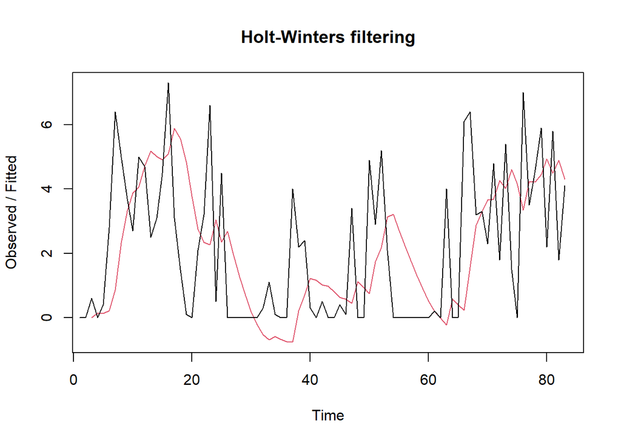

```r
#Lamda=0.2 dan gamma=0.2
des.1<- HoltWinters(train.ts, gamma = FALSE, beta = 0.2, alpha = 0.2)
plot(des.1)
```

```r
#ramalan
ramalandes1<- forecast(des.1, h=17)
ramalandes1
```

```
##     Point Forecast       Lo 80     Hi 80      Lo 95     Hi 95
##  84       4.278464  1.32396514  7.232964 -0.2400523  8.796981
##  85       4.294422  1.25602381  7.332819 -0.3524068  8.941250
##  86       4.310379  1.16137562  7.459381 -0.5056058  9.126363
##  87       4.326336  1.03846760  7.614204 -0.7020246  9.354696
##  88       4.342293  0.88666491  7.797920 -0.9426339  9.627219
##  89       4.358250  0.70612513  8.010374 -1.2271928  9.943692
##  90       4.374207  0.49761530  8.250798 -1.5545282 10.302942
##  91       4.390164  0.26231468  8.518013 -1.9228366 10.703164
##  92       4.406121  0.00163698  8.810605 -2.3299559 11.142197
##  93       4.422078 -0.28291026  9.127066 -2.7735805 11.617736
##  94       4.438035 -0.58982521  9.465895 -3.2514135 12.127483
##  95       4.453992 -0.91767475  9.825658 -3.7612633 12.669247
##  96       4.469949 -1.26512936 10.205027 -4.3010964 13.240994
##  97       4.485906 -1.63097814 10.602790 -4.8690610 13.840873
##  98       4.501863 -2.01413117 11.017857 -5.4634901 14.467216
##  99       4.517820 -2.41361435 11.449254 -6.0828940 15.118534
## 100       4.533777 -2.82856033 11.896114 -6.7259463 15.793500
```

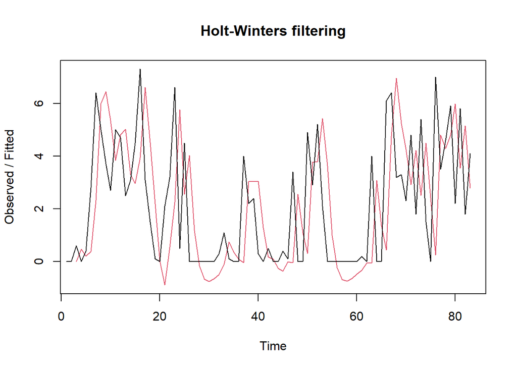

```r
#Lamda=0.6 dan gamma=0.3
des.2<- HoltWinters(train.ts, gamma = FALSE, beta = 0.3, alpha = 0.6)
plot(des.2)
```

```r
#ramalan
ramalandes2<- forecast(des.2, h=17)
ramalandes2
```

```
##     Point Forecast       Lo 80     Hi 80      Lo 95     Hi 95
##  84       3.452495   0.3481339  6.556856  -1.295216  8.200205
##  85       3.332645  -0.6043896  7.269680  -2.688530  9.353820
##  86       3.212795  -1.7249930  8.150584  -4.338900 10.764491
##  87       3.092946  -2.9820913  9.167983  -6.198022 12.383913
##  88       2.973096  -4.3547744 10.300966  -8.233915 14.180107
##  89       2.853246  -5.8289806 11.535473 -10.425074 16.131566
##  90       2.733397  -7.3948163 12.861609 -12.756368 18.223161
##  91       2.613547  -9.0449719 14.272065 -15.216619 20.443712
##  92       2.493697 -10.7738060 15.761200 -17.797198 22.784592
##  93       2.373847 -12.5768019 17.324496 -20.491197 25.238892
##  94       2.253998 -14.4502343 18.958229 -23.292920 27.800916
##  95       2.134148 -16.3909560 20.659252 -26.197554 30.465849
##  96       2.014298 -18.3962560 22.424852 -29.200951 33.229547
##  97       1.894448 -20.4637624 24.252659 -32.299484 36.088381
##  98       1.774599 -22.5913728 26.140570 -35.489939 39.039136
##  99       1.654749 -24.7772037 28.086701 -38.769434 42.078932
## 100       1.534899 -27.0195530 30.089351 -42.135367 45.205165
```

Selanjutnya jika ingin membandingkan plot data latih dan data uji adalah sebagai berikut.

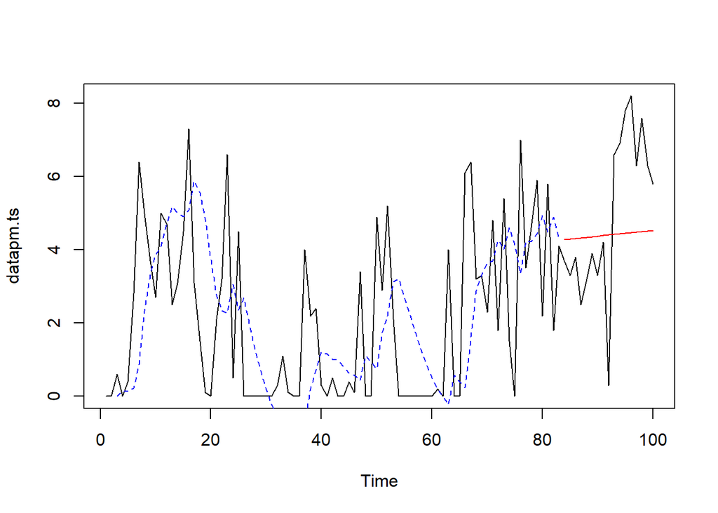

```r
#Visually evaluate the prediction
plot(datapm.ts)
lines(des.1$fitted[,1], lty=2, col="blue")
lines(ramalandes1$mean, col="red")
```

Untuk mendapatkan nilai parameter optimum dari DES, argumen `alpha` dan `beta` dapat dibuat `NULL` seperti berikut.

```r
#Lamda dan gamma optimum
des.opt<- HoltWinters(train.ts, gamma = FALSE)
des.opt
```

```
## Holt-Winters exponential smoothing with trend and without seasonal component.
##
## Call:
## HoltWinters(x = train.ts, gamma = FALSE)
##
## Smoothing parameters:
##  alpha: 0.3305455
##  beta : 0
##  gamma: FALSE
##
## Coefficients:
##       [,1]
## a 3.753181
## b 0.000000
```

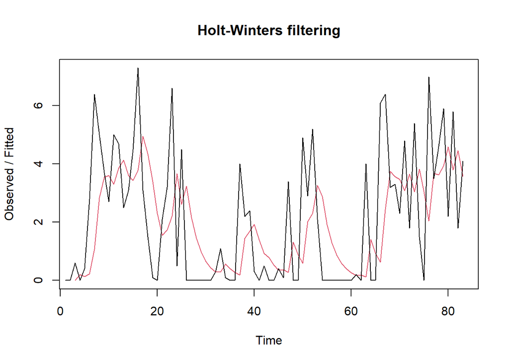

```r
plot(des.opt)
```

```r
#ramalan
ramalandesopt<- forecast(des.opt, h=17)
ramalandesopt
```

```
##     Point Forecast       Lo 80    Hi 80      Lo 95     Hi 95
##  84       3.753181  1.04097650 6.465386 -0.3947781  7.901141
##  85       3.753181  0.89664845 6.609714 -0.6155088  8.121872
##  86       3.753181  0.75926998 6.747093 -0.8256110  8.331974
##  87       3.753181  0.62792451 6.878438 -1.0264866  8.532849
##  88       3.753181  0.50188078 7.004482 -1.2192538  8.725617
##  89       3.753181  0.38054433 7.125819 -1.4048219  8.911185
##  90       3.753181  0.26342412 7.242939 -1.5839418  9.090305
##  91       3.753181  0.15010896 7.356254 -1.7572424  9.263605
##  92       3.753181  0.04025047 7.466112 -1.9252564  9.431619
##  93       3.753181 -0.06644962 7.572812 -2.0884402  9.594803
##  94       3.753181 -0.17024901 7.676612 -2.2471876  9.753550
##  95       3.753181 -0.27137215 7.777735 -2.4018421  9.908205
##  96       3.753181 -0.37001595 7.876379 -2.5527048 10.059068
##  97       3.753181 -0.46635429 7.972717 -2.7000416 10.206404
##  98       3.753181 -0.56054165 8.066904 -2.8440887 10.350452
##  99       3.753181 -0.65271597 8.159079 -2.9850572 10.491420
## 100       3.753181 -0.74300106 8.249364 -3.1231363 10.629499
```

Selanjutnya akan dilakukan perhitungan akurasi pada data latih maupun data uji dengan ukuran akurasi SSE, MSE dan MAPE.

#### Akurasi Data Latih

```r
#Akurasi Data Training
ssedes.train1<-des.1$SSE
msedes.train1<-ssedes.train1/length(train.ts)
sisaandes1<-ramalandes1$residuals
head(sisaandes1)
```

```
## Time Series:
## Start = 1
## End = 6
## Frequency = 1
## [1]         NA         NA  0.5990000 -0.1437600  0.2657824  2.5837850
```

```r
mapedes.train1 <- sum(abs(sisaandes1[3:length(train.ts)]/train.ts[3:length(train.ts)])
                      *100)/length(train.ts)

akurasides.1 <- matrix(c(ssedes.train1,msedes.train1,mapedes.train1))
row.names(akurasides.1)<- c("SSE", "MSE", "MAPE")
colnames(akurasides.1) <- c("Akurasi lamda=0.2 dan gamma=0.2")
akurasides.1
```

```
##      Akurasi lamda=0.2 dan gamma=0.2
## SSE                       425.194484
## MSE                         5.122825
## MAPE                    42451.910776
```

```r
ssedes.train2<-des.2$SSE
msedes.train2<-ssedes.train2/length(train.ts)
sisaandes2<-ramalandes2$residuals
head(sisaandes2)
```

```
## Time Series:
## Start = 1
## End = 6
## Frequency = 1
## [1]         NA         NA  0.5990000 -0.4672200  0.1883916  2.4177258
```

```r
mapedes.train2 <- sum(abs(sisaandes2[3:length(train.ts)]/train.ts[3:length(train.ts)])
                      *100)/length(train.ts)

akurasides.2 <- matrix(c(ssedes.train2,msedes.train2,mapedes.train2))
row.names(akurasides.2)<- c("SSE", "MSE", "MAPE")
colnames(akurasides.2) <- c("Akurasi lamda=0.6 dan gamma=0.3")
akurasides.2
```

```
##      Akurasi lamda=0.6 dan gamma=0.3
## SSE                       469.426202
## MSE                         5.655737
## MAPE                    33853.984112
```

Hasil akurasi dari data latih didapatkan skenario 1 dengan lamda=0.2 dan gamma=0.2 memiliki hasil yang lebih baik. Namun untuk kedua skenario dapat dikategorikan peramalan sangat buru berdasarkan nilai MAPE-nya.

#### Akurasi Data Uji

```r
#Akurasi Data Testing
selisihdes1<-ramalandes1$mean-testing$SS
selisihdes1
```

```
## Time Series:
## Start = 84
## End = 100
## Frequency = 1
##  [1]  0.5784645  0.9944215  0.5103786  1.8263356  1.1422926  0.4582497
##  [7]  1.0742067  0.1901637  4.1061207 -2.1779222 -2.4619652 -3.3460082
## [13] -3.7300511 -1.8140941 -3.0981371 -1.7821800 -1.2662230
```

```r
SSEtestingdes1<-sum(selisihdes1^2)
MSEtestingdes1<-SSEtestingdes1/length(testing$SS)
MAPEtestingdes1<-sum(abs(selisihdes1/testing$SS)*100)/length(testing$SS)

selisihdes2<-ramalandes2$mean-testing$SS
selisihdes2
```

```
## Time Series:
## Start = 84
## End = 100
## Frequency = 1
##  [1] -0.24750507  0.03264519 -0.58720454  0.59294572 -0.22690402 -1.04675375
##  [7] -0.56660349 -1.58645323  2.19369704 -4.22615270 -4.64600244 -5.66585217
## [13] -6.18570191 -4.40555165 -5.82540138 -4.64525112 -4.26510085
```

```r
SSEtestingdes2<-sum(selisihdes2^2)
MSEtestingdes2<-SSEtestingdes2/length(testing$SS)
MAPEtestingdes2<-sum(abs(selisihdes2/testing$SS)*100)/length(testing$SS)

selisihdesopt<-ramalandesopt$mean-testing$SS
selisihdesopt
```

```
## Time Series:
## Start = 84
## End = 100
## Frequency = 1
##  [1]  0.05318142  0.45318142 -0.04681858  1.25318142  0.55318142 -0.14681858
##  [7]  0.45318142 -0.44681858  3.45318142 -2.84681858 -3.14681858 -4.04681858
## [13] -4.44681858 -2.54681858 -3.84681858 -2.54681858 -2.04681858
```

```r
SSEtestingdesopt<-sum(selisihdesopt^2)
MSEtestingdesopt<-SSEtestingdesopt/length(testing$SS)
MAPEtestingdesopt<-sum(abs(selisihdesopt/testing$SS)*100)/length(testing$SS)

akurasitestingdes <-
  matrix(c(SSEtestingdes1,MSEtestingdes1,MAPEtestingdes1,SSEtestingdes2,MSEtestingdes2,
           MAPEtestingdes2,SSEtestingdesopt,MSEtestingdesopt,MAPEtestingdesopt),
         nrow=3,ncol=3)
row.names(akurasitestingdes)<- c("SSE", "MSE", "MAPE")
colnames(akurasitestingdes) <- c("des ske1","des ske2","des opt")
akurasitestingdes
```

```
##        des ske1  des ske2    des opt
## SSE   78.067165 212.48020 100.555733
## MSE    4.592186  12.49884   5.915043
## MAPE 109.543008  84.72029  95.565975
```

#### Perbandingan SES dan DES

```r
MSEfull <-
  matrix(c(MSEtesting1,MSEtesting2,MSEtestingopt,MSEtestingdes1,MSEtestingdes2,
           MSEtestingdesopt),nrow=3,ncol=2)
row.names(MSEfull)<- c("ske 1", "ske 2", "ske opt")
colnames(MSEfull) <- c("ses","des")
MSEfull
```

```
##              ses       des
## ske 1   50.46984  4.592186
## ske 2   51.37742 12.498835
## ske opt 50.27790  5.915043
```

Kedua metode dapat dibandingkan dengan menggunakan ukuran akurasi yang sama. Contoh di atas adalah perbandingan kedua metode dengan ukuran akurasi MSE. Hasilnya didapatkan metode DES lebih baik dibandingkan metode SES dilihat dari MSE yang lebih kecil nilainya.

## Pemulusan Data Musiman

Selanjutnya melakukan pembagian data dan mengubahnya menjadi data deret waktu.

```r
#membagi data menjadi training dan testing
training<-data.pm[1:83,2]
testing<-data.pm[84:100,2]
training.ts<-ts(training, frequency = 10)
testing.ts<-ts(testing, frequency = 10)
```

### Winter Aditif

Perhitungan dengan model aditif dilakukan jika plot data asli menunjukkan fluktuasi musiman yang relatif stabil (konstan).

#### Pemulusan

```r
#Pemulusan dengan winter aditif
winter1 <- HoltWinters(training.ts,alpha=0.2,beta=0.1,gamma=0.1,seasonal = "additive")
winter1$fitted
```

```
## Time Series:
## Start = c(2, 1)
## End = c(9, 3)
## Frequency = 10
##            xhat     level        trend      season
## 2.0  3.21985182 2.8671767  0.121615152  0.23106000
## 2.1  3.37309957 3.3448215  0.157218115 -0.12894000
## 2.2  1.96223578 3.7674197  0.183756124 -1.98894000
## 2.3  3.21930003 4.0587286  0.194511408 -1.03394000
## 2.4  5.10251543 4.2293800  0.192125408  0.68101000
## 2.5  4.36688745 4.3010023  0.180075099 -0.11419000
## 2.6  8.30734731 5.0677000  0.238737350  3.00091000
## 2.7  5.67051825 4.2649678  0.134590404  1.27096000
## 2.8  3.33764464 3.5654546  0.051180039 -0.27899000
## 2.9  1.31659286 2.9691057 -0.013572854 -1.63894000
## 3.0  3.02600143 2.6924143 -0.039884711  0.37347185
## 3.1  2.38613658 2.4673293 -0.058404740 -0.02278797
## 3.2  0.58365090 2.5716972 -0.042127471 -1.94591886
## 3.3  2.76755509 3.7328396  0.078199511 -1.04348400
## 3.4  4.02318525 3.3575281  0.032848409  0.63280877
## 3.5  3.64858314 3.4857394  0.042384704  0.12045900
## 3.6  5.35236277 2.7986075 -0.030566959  2.58432222
## 3.7  2.49749232 1.6977680 -0.137594214  0.93731854
## 3.8  0.33534969 1.0608753 -0.187524061 -0.53800157
## 3.9 -1.13191716 0.8064813 -0.194211054 -1.74418743
## 4.0  0.96669273 0.8388537 -0.171552711  0.29939174
## 4.1  0.32561698 0.4741624 -0.190866566  0.04232111
## 4.2 -1.37781736 0.2781725 -0.191378905 -1.46461093
## 4.3 -0.78435392 0.5823570 -0.141822558 -1.22488841
## 4.4  1.16422374 0.6174053 -0.124135480  0.67095395
## 4.5 -0.05812256 0.2606250 -0.147399954 -0.17134765
## 4.6  2.13504529 0.1250496 -0.146217503  2.15621319
## 4.7  0.98050379 0.3518230 -0.108918409  0.73759915
## 4.8 -0.16247416 0.4868039 -0.084528485 -0.56474955
## 4.9 -0.77206284 0.9147702 -0.033279002 -1.65355406
## 5.0  1.30620236 1.0959038 -0.011837745  0.22213632
## 5.1  0.82535553 0.8230256 -0.037941792  0.04027175
## 5.2 -0.59082178 0.7200127 -0.044448903 -1.26638555
## 5.3 -0.39282444 0.7939281 -0.032612467 -1.15414010
## 5.4  1.39324061 0.8400805 -0.024735978  0.57789605
```

[output cut: 23 more lines]

```
## 7.8  2.43064424 2.6496270  0.139937997 -0.35892080
## 7.9  2.11176735 2.9634362  0.157325113 -1.00899395
## 8.0  3.50357637 3.1584078  0.161089766  0.18407877
## 8.1  4.00430961 3.5787823  0.187018238  0.23850905
## 8.2  2.70993663 3.3249386  0.142932046 -0.75793406
## 8.3  2.94757037 4.0058834  0.196733314 -1.25504630
## 8.4  4.21153188 3.9131026  0.167781906  0.13064738
## 8.5  3.42319523 3.2387781  0.083571269  0.10084584
## 8.6  6.40308230 4.0377104  0.155107364  2.21026459
## 8.7  4.29908784 3.6122013  0.097045718  0.58984087
## 8.8  3.58312103 3.7694294  0.103063961 -0.28937234
## 8.9  3.49133536 4.3358692  0.149401540 -0.99393534
## 9.0  4.63837112 4.2270036  0.123574833  0.28779266
## 9.1  4.79187593 4.5829042  0.146807411  0.06216428
## 9.2  3.67557737 4.1313365  0.086969892 -0.54272899
```

```r
xhat1 <- winter1$fitted[,2]

winter1.opt<- HoltWinters(training.ts, alpha= NULL,  beta = NULL, gamma = NULL, seasonal = "additive")
winter1.opt
```

```
## Holt-Winters exponential smoothing with trend and additive seasonal component.
##
## Call:
## HoltWinters(x = training.ts, alpha = NULL, beta = NULL, gamma = NULL,     seasonal = "additive")
##
## Smoothing parameters:
##  alpha: 0.3773519
##  beta : 0.001571366
##  gamma: 0.4280807
##
## Coefficients:
##           [,1]
## a    3.9397743
## b    0.1101677
## s1  -2.2673219
## s2  -2.0480798
## s3   1.2781030
## s4   0.5445843
## s5  -0.3353670
## s6  -0.2019870
## s7  -1.4513142
## s8   0.2378325
## s9  -1.3933489
## s10  0.4910849
```

```r
winter1.opt$fitted
```

```
## Time Series:
## Start = c(2, 1)
## End = c(9, 3)
## Frequency = 10
##            xhat     level     trend       season
## 2.0  3.21985182 2.8671767 0.1216152  0.231060000
## 2.1  3.65426488 3.6605342 0.1226707 -0.128940000
## 2.2  2.31216583 4.1778150 0.1232908 -1.988940000
## 2.3  3.46144757 4.3719854 0.1234022 -1.033940000
## 2.4  5.16319247 4.3589946 0.1231878  0.681010000
## 2.5  4.24053010 4.2319255 0.1227946 -0.114190000
## 2.6  8.63473570 5.5092170 0.1246087  3.000910000
## 2.7  4.93756936 3.5452825 0.1213269  1.270960000
## 2.8  2.20973445 2.3694359 0.1192885 -0.278990000
## 2.9  0.17170963 1.6926121 0.1180375 -1.638940000
## 3.0  2.56971545 1.7462320 0.1179363  0.705547108
## 3.1  1.95437211 1.6869203 0.1176578  0.149794006
## 3.2  0.45414060 2.2746182 0.1183964 -1.938874003
## 3.3  3.70392561 4.7121665 0.1220406 -1.130281538
## 3.4  4.24958077 3.6251996 0.1201408  0.504240290
## 3.5  4.66141812 3.8398367 0.1202893  0.701292126
## 3.6  3.84469573 2.2015082 0.1175259  1.525661611
## 3.7  1.33855275 0.8686081 0.1152468  0.354697882
## 3.8 -0.24774583 0.4791268 0.1144536 -0.841326219
## 3.9 -0.88239531 0.6874451 0.1146011 -1.684441558
## 4.0  1.83086958 1.1353972 0.1151250  0.580347461
## 4.1  1.15586537 0.5600173 0.1140399  0.481808150
## 4.2  0.16389269 0.3510948 0.1135324 -0.300734502
## 4.3 -1.05231082 0.8178691 0.1140875 -1.984267411
## 4.4  2.05254200 1.3667833 0.1147708  0.570987933
## 4.5  0.28004252 0.7074007 0.1135543 -0.540912506
## 4.6  1.33019573 0.7156578 0.1133888  0.501149107
## 4.7  1.94965608 1.8365024 0.1149719 -0.001818245
## 4.8  1.38603783 2.0459421 0.1151204 -0.775024611
## 4.9  1.21042643 2.5436830 0.1157216 -1.448978190
## 5.0  2.52364262 2.3158534 0.1151817  0.092607431
## 5.1  1.84647976 1.4791111 0.1136859  0.253682712
## 5.2  1.14636674 1.0847003 0.1128875 -0.051221088
## 5.3 -0.79953649 0.7653815 0.1122084 -1.677126334
## 5.4  1.31651942 1.1796738 0.1126830  0.024162539
```

[output cut: 23 more lines]

```
## 7.8  3.80084985 4.3290427 0.1134190 -0.641611852
## 7.9  4.02974787 4.2534650 0.1131220 -0.336839201
## 8.0  3.33731026 3.7138634 0.1120964 -0.488649466
## 8.1  4.57558778 4.3779085 0.1129637  0.084715586
## 8.2  3.89145658 3.4434988 0.1113179  0.336639932
## 8.3  2.13938209 4.1240684 0.1122124 -2.096898698
## 8.4  2.80656843 3.9950087 0.1118332 -1.300273534
## 8.5  3.50480650 3.0481553 0.1101697  0.346481548
## 8.6  5.72790260 4.4772430 0.1122422  1.138417469
## 8.7  3.13343140 3.7487818 0.1109211 -0.726271487
## 8.8  3.74979593 4.4131154 0.1117907 -0.775110175
## 8.9  4.65146303 5.3362898 0.1130657 -0.797892428
## 9.0  4.53712436 4.5242912 0.1116121 -0.098778875
## 9.1  4.56971314 5.1124518 0.1123609 -0.655099578
## 9.2  5.02910724 4.1796561 0.1107186  0.738732527
```

```r
xhat1.opt <- winter1.opt$fitted[,2]
```

#### Peramalan

```r
#Forecast
forecast1 <- predict(winter1, n.ahead = 17)
forecast1.opt <- predict(winter1.opt, n.ahead = 17)
```

#### Plot Deret Waktu

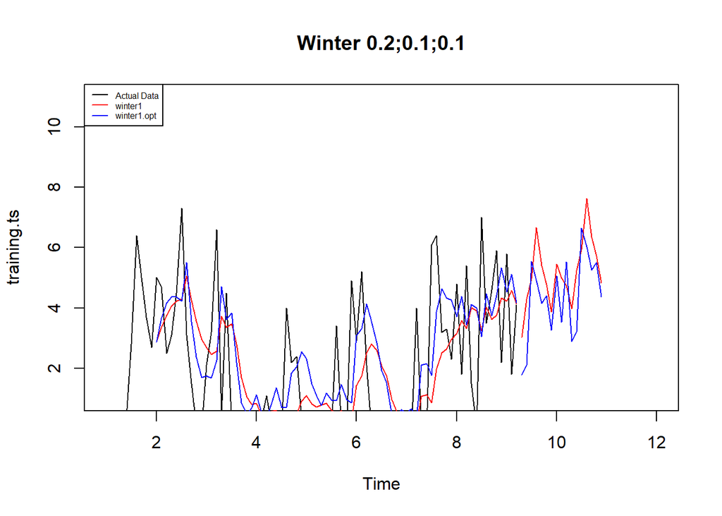

```r
#Plot time series
plot(training.ts,main="Winter 0.2;0.1;0.1",type="l",col="black",
     xlim=c(1,12), ylim=c(1,11),pch=12)
lines(xhat1,type="l",col="red")
lines(xhat1.opt,type="l",col="blue")
lines(forecast1,type="l",col="red")
lines(forecast1.opt,type="l",col="blue")
legend("topleft",c("Actual Data",expression(paste(winter1)),
                   expression(paste(winter1.opt))),cex=0.5,
       col=c("black","red","blue"),lty=1)
```

#### Akurasi Data Latih

```r
#Akurasi data training
SSE1<-winter1$SSE
MSE1<-winter1$SSE/length(training.ts)
RMSE1<-sqrt(MSE1)
akurasi1 <- matrix(c(SSE1,MSE1,RMSE1))
row.names(akurasi1)<- c("SSE", "MSE", "RMSE")
colnames(akurasi1) <- c("Akurasi")
akurasi1
```

```
##         Akurasi
## SSE  420.630233
## MSE    5.067834
## RMSE   2.251185
```

```r
SSE1.opt<-winter1.opt$SSE
MSE1.opt<-winter1.opt$SSE/length(training.ts)
RMSE1.opt<-sqrt(MSE1.opt)
akurasi1.opt <- matrix(c(SSE1.opt,MSE1.opt,RMSE1.opt))
row.names(akurasi1.opt)<- c("SSE1.opt", "MSE1.opt", "RMSE1.opt")
colnames(akurasi1.opt) <- c("Akurasi")
akurasi1.opt
```

```
##              Akurasi
## SSE1.opt  366.602971
## MSE1.opt    4.416903
## RMSE1.opt   2.101643
```

```r
akurasi1.train = data.frame(Model_Winter = c("Winter 1","Winter1 optimal"),
                            Nilai_SSE=c(SSE1,SSE1.opt),
                            Nilai_MSE=c(MSE1,MSE1.opt),Nilai_RMSE=c(RMSE1,RMSE1.opt))
akurasi1.train
```

```
##      Model_Winter Nilai_SSE Nilai_MSE Nilai_RMSE
## 1        Winter 1  420.6302  5.067834   2.251185
## 2 Winter1 optimal  366.6030  4.416903   2.101643
```

#### Akurasi Data Uji

```r
#Akurasi Data Testing
forecast1<-data.frame(forecast1)
testing.ts<-data.frame(testing.ts)
selisih1<-forecast1-testing.ts
SSEtesting1<-sum(selisih1^2)
MSEtesting1<-SSEtesting1/length(testing.ts)

forecast1.opt<-data.frame(forecast1.opt)
selisih1.opt<-forecast1.opt-testing.ts
SSEtesting1.opt<-sum(selisih1.opt^2)
MSEtesting1.opt<-SSEtesting1.opt/length(testing.ts)
```

### Winter Multiplikatif

Model multiplikatif digunakan cocok digunakan jika plot data asli menunjukkan fluktuasi musiman yang bervariasi.

#### Pemulusan

```r
#Pemulusan dengan winter multiplikatif
winter2 <- HoltWinters(training.ts,alpha=0.2,beta=0.1,gamma=0.3,seasonal = "multiplicative")
winter2$fitted
```

```
## Time Series:
## Start = c(2, 1)
## End = c(9, 3)
## Frequency = 10
##            xhat      level       trend    season
## 2.0  2.97208132  2.8671767  0.12161515 0.9944089
## 2.1  3.28065684  3.3966559  0.16240156 0.9217769
## 2.2  2.16060089  3.8670156  0.19319737 0.5321398
## 2.3  3.18274717  4.1877731  0.20595339 0.7243845
## 2.4  5.26726020  4.3708803  0.20366877 1.1514272
## 2.5  4.56397094  4.4412779  0.19034165 0.9853942
## 2.6 10.18702650  5.1869362  0.24587332 1.8750936
## 2.7  6.37426350  4.6768978  0.17028214 1.3150458
## 2.8  3.79501311  4.1058729  0.09615144 0.9031393
## 2.9  2.02930493  3.3837644  0.01432545 0.5971899
## 3.0  3.03219473  2.7188068 -0.05360286 1.1376971
## 3.1  2.45532747  2.5013300 -0.06999026 1.0098661
## 3.2  1.39198141  2.5788192 -0.05524231 0.5515907
## 3.3  3.27206168  4.4119405  0.13359405 0.7198409
## 3.4  4.25330222  3.7753472  0.05657532 1.1099656
## 3.5  4.37834514  3.8763739  0.06102046 1.1119905
## 3.6  4.73433605  3.1500954 -0.01770944 1.5114153
## 3.7  2.49878622  2.5060411 -0.08034393 1.0301312
## 3.8  1.16155128  1.9407519 -0.12883845 0.6410633
## 3.9  0.53722930  1.4498427 -0.16504552 0.4181433
## 4.0  0.87804102  1.0283161 -0.19069364 1.0482540
## 4.1  0.49950632  0.6702887 -0.20742701 1.0791697
## 4.2  0.17930490  0.4258877 -0.21112441 0.8348956
## 4.3  0.13386511  0.4353166 -0.18906908 0.5436201
## 4.4  0.04891804  0.2337884 -0.19031499 1.1252395
## 4.5 -0.12160784  0.0349565 -0.19116668 0.7784886
## 4.6 -0.33090078 -0.1247112 -0.18801679 1.0581104
## 4.7  0.28830136  0.5058823 -0.10615575 0.7212464
## 4.8  0.39359177  0.9298363 -0.05314478 0.4489513
## 4.9  0.52936300  1.7705116  0.03623723 0.2929920
## 5.0  1.22671685  1.6501828  0.02058062 0.7342253
## 5.1  1.28003972  1.3368831 -0.01280740 0.9667421
## 5.2  1.52206255  1.1627008 -0.02894490 1.3424958
## 5.3  0.43535034  0.9071537 -0.05160512 0.5088552
## 5.4  0.49061337  0.6848319 -0.06867679 0.7962498
```

[output cut: 23 more lines]

```
## 7.8  1.71926238  4.6073778  0.24430501 0.3543641
## 7.9  2.37857511  5.7438373  0.33352045 0.3913831
## 8.0  2.94868273  6.0372052  0.32950520 0.4631407
## 8.1  4.60526265  7.1661725  0.40945141 0.6079054
## 8.2 10.22639500  6.6526966  0.31715867 1.4672321
## 8.3  1.14925770  6.3119641  0.25136956 0.1751027
## 8.4  2.70389584  6.9639468  0.29143087 0.3726747
## 8.5  3.76839606  5.8048388  0.14637699 0.6332145
## 8.6 17.95514811  6.9719138  0.24844679 2.4867384
## 8.7  3.87190505  6.0577817  0.13218890 0.6255127
## 8.8  2.76558066  6.4227700  0.15546884 0.4204135
## 8.9  3.25125814  8.0693514  0.30458009 0.3882595
## 9.0  4.24464118  7.8324079  0.25042774 0.5251426
## 9.1  4.55266122  8.6751924  0.30966342 0.5067039
## 9.2 10.39730944  7.8983588  0.20101371 1.2837179
```

```r
xhat2 <- winter2$fitted[,2]

winter2.opt<- HoltWinters(training.ts, alpha= NULL,  beta = NULL, gamma = NULL, seasonal = "multiplicative")
winter2.opt$fitted
```

```
## Time Series:
## Start = c(2, 1)
## End = c(9, 3)
## Frequency = 10
##           xhat     level      trend    season
## 2.0  2.9720813 2.8671767 0.12161515 0.9944089
## 2.1  3.3614966 3.5230660 0.12369141 0.9217769
## 2.2  2.2096334 4.0271853 0.12516981 0.5321398
## 2.3  3.2025294 4.2953102 0.12572535 0.7243845
## 2.4  5.1924015 4.3839540 0.12558125 1.1514272
## 2.5  4.4115712 4.3519918 0.12496901 0.9853942
## 2.6 10.0746148 5.2449063 0.12795335 1.8750936
## 2.7  5.9473461 4.3983728 0.12416636 1.3150458
## 2.8  3.3933220 3.6365290 0.12072321 0.9031393
## 2.9  1.7431510 2.8019118 0.11701063 0.5971899
## 3.0  2.3900372 2.1546433 0.11404053 1.0534907
## 3.1  2.2084119 2.1965562 0.11376024 0.9558915
## 3.2  1.4538421 2.5820863 0.11481637 0.5390785
## 3.3  3.8426987 5.1978803 0.12453551 0.7219839
## 3.4  4.8006340 4.1094505 0.11982176 1.1350969
## 3.5  4.4588307 4.1598844 0.11955211 1.0419200
## 3.6  5.6057135 3.1585340 0.11519613 1.7123322
## 3.7  3.0071917 2.4162105 0.11186369 1.1895188
## 3.8  1.5456364 1.8659735 0.10929068 0.7824960
## 3.9  0.8049198 1.4581067 0.10728094 0.5141984
## 4.0  1.3118566 1.1557870 0.10568918 1.0399377
## 4.1  1.0307857 0.9312385 0.10440583 0.9953085
## 4.2  0.6067060 0.8432860 0.10365830 0.6406987
## 4.3  0.8000949 1.1486559 0.10444217 0.6384935
## 4.4  1.2056707 0.9658354 0.10332583 1.1276791
## 4.5  0.7997487 0.7892879 0.10223821 0.8970558
## 4.6  1.1198078 0.6582505 0.10133167 1.4742418
## 4.7  1.4079495 1.2714189 0.10332073 1.0241573
## 4.8  1.1329058 1.5773515 0.10410811 0.6737633
## 4.9  1.0096749 2.1741569 0.10602280 0.4428050
## 5.0  1.7592907 1.8602993 0.10439109 0.8954544
## 5.1  1.4072626 1.4502609 0.10239194 0.9063601
## 5.2  0.9530598 1.2904056 0.10137282 0.6847784
## 5.3  0.6360097 1.0275341 0.09995731 0.5640928
## 5.4  0.9043880 0.8325685 0.09881120 0.9710198
```

[output cut: 23 more lines]

```
## 7.8  2.2374679 4.0108026 0.10193577 0.5440336
## 7.9  2.1476081 4.6244143 0.10392421 0.4541993
## 8.0  3.4498109 4.8162396 0.10426581 0.7011091
## 8.1  4.1760693 5.4250362 0.10622648 0.7549938
## 8.2  3.5298938 4.7067557 0.10302234 0.7338995
## 8.3  2.0109200 5.4773657 0.10561667 0.3601874
## 8.4  3.5699389 5.2113590 0.10417250 0.6716053
## 8.5  2.9399714 3.9233249 0.09876219 0.7309567
## 8.6  9.1200424 5.4772651 0.10441721 1.6339236
## 8.7  3.8136370 4.6805543 0.10091531 0.7975868
## 8.8  2.9185104 5.0397692 0.10191909 0.5676171
## 8.9  3.0306211 6.5178088 0.10726688 0.4574470
## 9.0  4.5450687 6.1493673 0.10541822 0.7266546
## 9.1  4.7917461 6.7072355 0.10717650 0.7031782
## 9.2  4.4618799 5.6997634 0.10284482 0.7689439
```

```r
xhat2.opt <- winter2.opt$fitted[,2]
```

#### Peramalan

```r
#Forecast
forecast2 <- predict(winter2, n.ahead = 17)
forecast2.opt <- predict(winter2.opt, n.ahead = 17)
```

#### Plot Deret Waktu

[figure not shown]

```r
#Plot time series
plot(training.ts,main="Winter 0.2;0.1;0.1",type="l",col="black",
     xlim=c(1,25),pch=12)
lines(xhat2,type="l",col="red")
lines(xhat2.opt,type="l",col="blue")
lines(forecast2,type="l",col="red")
lines(forecast2.opt,type="l",col="blue")
legend("topleft",c("Actual Data",expression(paste(winter2)),
                   expression(paste(winter2.opt))),cex=0.5,
       col=c("black","red","blue"),lty=1)
```

#### Akurasi Data Latih

```r
#Akurasi data training
SSE2<-winter2$SSE
MSE2<-winter2$SSE/length(training.ts)
RMSE2<-sqrt(MSE2)
akurasi1 <- matrix(c(SSE2,MSE2,RMSE2))
row.names(akurasi1)<- c("SSE2", "MSE2", "RMSE2")
colnames(akurasi1) <- c("Akurasi lamda=0.2")
akurasi1
```

```
##       Akurasi lamda=0.2
## SSE2          854.09524
## MSE2           10.29030
## RMSE2           3.20785
```

```r
SSE2.opt<-winter2.opt$SSE
MSE2.opt<-winter2.opt$SSE/length(training.ts)
RMSE2.opt<-sqrt(MSE2.opt)
akurasi1.opt <- matrix(c(SSE2.opt,MSE2.opt,RMSE2.opt))
row.names(akurasi1.opt)<- c("SSE2.opt", "MSE2.opt", "RMSE2.opt")
colnames(akurasi1.opt) <- c("Akurasi")
akurasi1.opt
```

```
##              Akurasi
## SSE2.opt  426.370241
## MSE2.opt    5.136991
## RMSE2.opt   2.266493
```

```r
akurasi2.train = data.frame(Model_Winter = c("Winter 1","winter2 optimal"),
                            Nilai_SSE=c(SSE2,SSE2.opt),
                            Nilai_MSE=c(MSE2,MSE2.opt),Nilai_RMSE=c(RMSE2,RMSE2.opt))
akurasi2.train
```

```
##      Model_Winter Nilai_SSE Nilai_MSE Nilai_RMSE
## 1        Winter 1  854.0952 10.290304   3.207850
## 2 winter2 optimal  426.3702  5.136991   2.266493
```

#### Akurasi Data Uji

```r
#Akurasi Data Testing
forecast2<-data.frame(forecast2)
testing.ts<-data.frame(testing.ts)
selisih2<-forecast2-testing.ts
SSEtesting2<-sum(selisih2^2)
MSEtesting2<-SSEtesting2/length(testing.ts)
```

```r
forecast2.opt<-data.frame(forecast2.opt)
selisih2.opt<-forecast2.opt-testing.ts
SSEtesting2.opt<-sum(selisih2.opt^2)
MSEtesting2.opt<-SSEtesting2.opt/length(testing.ts)
```

```r
akurasitesting1 <- matrix(c(SSEtesting2,SSEtesting2.opt))
row.names(akurasitesting1)<- c("SSE2", "SSEopt")
akurasitesting1
```

```
##            [,1]
## SSE2   349.5991
## SSEopt 144.5089
```

```r
akurasitesting2 <- matrix(c(MSEtesting2,MSEtesting2.opt))
row.names(akurasitesting2)<- c("MSE2", "MSEopt")
akurasitesting2
```

```
##            [,1]
## MSE2   349.5991
## MSEopt 144.5089
```